# Análise Mestrado

Vitor Sain Vallio

## Ler dataset

```r
df <- readxl::read_excel("../dados/2019-10-16 AFAQ 2019.xlsx", sheet = 1)

df <- janitor::clean_names(df)
```

## Tabela 1

### limpeza tabela 1

```r
df2 <- df %>%
  select("sexo":"pratica_outro_esporte")
```

### visualizar

```r
glimpse(df2)
```

```
## Observations: 100
## Variables: 14
## $ sexo                                                         <chr> "Ma…
## $ peso_kg                                                      <dbl> 85,…
## $ altura_m                                                     <dbl> 188…
## $ data_de_nascimento_dia_mes_ano                               <chr> "01…
## $ nivel_de_escolaridade                                        <chr> "Gr…
## $ voce_pratica_sua_modalidade_quantas_vezes_por_semana         <chr> "3 …
## $ devido_a_sua_queixa_lesao_no_ultimo_ano                      <chr> "Vo…
## $ participa_participou_de_campeonato_e_ou_competicao           <chr> "Si…
## $ possui_renda_pelo_esporte                                    <chr> "Nã…
## $ qual_esporte_voce_pratica_profissionalmente_competitivamente <chr> "Ba…
## $ o_esporte_que_voce_pratica_e                                 <chr> "Co…
## $ quanto_tempo_de_experiencia_possui_no_esporte_meses          <dbl> 300…
## $ quantas_horas_de_treino_voce_faz_na_semana                   <dbl> 3, …
## $ pratica_outro_esporte                                        <chr> "Nã…
```

```r
summary(df2)
```

```
##      sexo              peso_kg          altura_m
##  Length:100         Min.   : 49.00   Min.   :150.0
##  Class :character   1st Qu.: 66.50   1st Qu.:168.0
##  Mode  :character   Median : 77.00   Median :175.0
##                     Mean   : 78.69   Mean   :174.1
##                     3rd Qu.: 88.25   3rd Qu.:180.2
##                     Max.   :140.00   Max.   :198.0
##
##  data_de_nascimento_dia_mes_ano nivel_de_escolaridade
##  Length:100                     Length:100
##  Class :character               Class :character
##  Mode  :character               Mode  :character
##
##
##
##
##  voce_pratica_sua_modalidade_quantas_vezes_por_semana
##  Length:100
##  Class :character
##  Mode  :character
##
##
##
##
##  devido_a_sua_queixa_lesao_no_ultimo_ano
##  Length:100
##  Class :character
##  Mode  :character
##
##
##
##
##  participa_participou_de_campeonato_e_ou_competicao
##  Length:100
##  Class :character
##  Mode  :character
##
##
##
##
```

[output cut: 25 more lines]

```
##  Min.   :  2.00
##  1st Qu.: 19.00
##  Median : 62.50
##  Mean   : 94.51
##  3rd Qu.:120.00
##  Max.   :960.00
##  NA's   :2
##  quantas_horas_de_treino_voce_faz_na_semana pratica_outro_esporte
##  Min.   : 0.000                             Length:100
##  1st Qu.: 3.000                             Class :character
##  Median : 6.000                             Mode  :character
##  Mean   : 7.768
##  3rd Qu.:10.000
##  Max.   :36.000
##  NA's   :1
```

### limpeza de dados

```r
df3 <- df2 %>%
  mutate(
    # dados categoricos
    sexo = as.factor(sexo),
    escolaridade = as.factor(nivel_de_escolaridade),
    vezes_por_semana = as.factor(voce_pratica_sua_modalidade_quantas_vezes_por_semana),
    lesao_no_ultimo_ano = as.factor(devido_a_sua_queixa_lesao_no_ultimo_ano),
    renda = as.factor(possui_renda_pelo_esporte),
    esporte = as.factor(qual_esporte_voce_pratica_profissionalmente_competitivamente),
    tipo_esporte = as.factor(o_esporte_que_voce_pratica_e),
    outro_esporte = as.factor(pratica_outro_esporte),

    #dados coninuos
    peso = as.double(peso_kg),
    altura = as.double(altura_m),
    nascimento = lubridate::dmy(data_de_nascimento_dia_mes_ano),
    idade = as.integer((lubridate::today() - nascimento)/365),
    experiencia = as.double(quanto_tempo_de_experiencia_possui_no_esporte_meses),
    horas_por_semana = as.integer(quantas_horas_de_treino_voce_faz_na_semana),

    #calculo de imc
    imc = round(peso/(altura/100)^2,1)
  ) %>%
  select(
    idade,
    peso,
    altura,
    imc,
    sexo,
    escolaridade,
    lesao_no_ultimo_ano,
    esporte,
    tipo_esporte,
    renda,
    experiencia,
    horas_por_semana,
    vezes_por_semana,
    outro_esporte


  )
```

### visualizar dados corrigidos

```r
glimpse(df3)
```

```
## Observations: 100
## Variables: 14
## $ idade               <int> 26, 40, 34, 24, 27, 27, 24, 22, 24, 26, 33, …
## $ peso                <dbl> 85, 52, 59, 70, 55, 58, 90, 50, 85, 96, 93, …
## $ altura              <dbl> 188, 152, 155, 163, 161, 161, 170, 150, 181,…
## $ imc                 <dbl> 24.0, 22.5, 24.6, 26.3, 21.2, 22.4, 31.1, 22…
## $ sexo                <fct> Masculino, Feminino, Feminino, Feminino, Fem…
## $ escolaridade        <fct> Graduação incompleta, Ensino medio completo,…
## $ lesao_no_ultimo_ano <fct> Você está afastado do esporte, Você está afa…
## $ esporte             <fct> Basquete, Futebol, Futsal, Handebol, Futsal,…
## $ tipo_esporte        <fct> Coletivo, Coletivo, Coletivo, Coletivo, Cole…
## $ renda               <fct> "Não recebo renda pelo esporte", "Não recebo…
## $ experiencia         <dbl> 300, 60, 22, 168, 240, 120, 5, 108, 84, 156,…
## $ horas_por_semana    <int> 3, 4, 13, 10, 4, 1, 3, 10, 4, 4, 12, 7, 6, 4…
## $ vezes_por_semana    <fct> 3 vezes por semana, 3 vezes por semana, 3 ve…
## $ outro_esporte       <fct> Não, Não, Não, Não, Sim, Sim, Sim, Não, Sim,…
```

```r
summary(df3)
```

```
##      idade            peso            altura           imc
##  Min.   :14.00   Min.   : 49.00   Min.   :150.0   Min.   :18.40
##  1st Qu.:23.00   1st Qu.: 66.50   1st Qu.:168.0   1st Qu.:22.18
##  Median :26.50   Median : 77.00   Median :175.0   Median :24.60
##  Mean   :28.51   Mean   : 78.69   Mean   :174.1   Mean   :25.79
##  3rd Qu.:33.00   3rd Qu.: 88.25   3rd Qu.:180.2   3rd Qu.:27.85
##  Max.   :57.00   Max.   :140.00   Max.   :198.0   Max.   :40.90
##
##         sexo                         escolaridade
##  Feminino :36   Ensino fundamental completo: 1
##  Masculino:64   Ensino medio completo      :21
##                 Ensino medio incompleto    : 4
##                 Graduação completa         :28
##                 Graduação incompleta       :32
##                 Pos-graduação completa     :10
##                 Pos-graduação incompleta   : 4
##                                lesao_no_ultimo_ano              esporte
##  Você está afastado do esporte           :39       Futebol          :21
##  Você está participando de forma reduzida:31       Futebol Americano:20
##  Você está treinando normalmente         :30       Rugby            :12
##                                                    Futsal           : 7
##                                                    Basquete         : 5
##                                                    (Other)          :31
##                                                    NA's             : 4
##      tipo_esporte                                 renda
##  Coletivo  :76    Não recebo renda pelo esporte      :85
##  individual:24    Perdi após a lesão                 : 5
##                   Sim, ministério do esporte         : 1
##                   Sim, pelo clube/grupo que participo: 8
##                   Sim, por patrocinador              : 1
##
##
##   experiencia     horas_por_semana           vezes_por_semana
##  Min.   :  2.00   Min.   : 0.000   3 vezes por semana:30
##  1st Qu.: 19.00   1st Qu.: 3.000   6 vezes por semana:14
##  Median : 62.50   Median : 6.000   2 vezes por semana:12
##  Mean   : 94.51   Mean   : 7.768   4 vezes por semana:12
##  3rd Qu.:120.00   3rd Qu.:10.000   5 vezes por semana:12
##  Max.   :960.00   Max.   :36.000   (Other)           :16
##  NA's   :2        NA's   :1        NA's              : 4
##  outro_esporte
##  Não:59
##  Sim:41
##
##
##
##
##
```

#### idade

```r
df3 %>%
  summarise(
    media = round(mean(idade),2),
    dp = round(sd(idade),2),
    mediana = median(idade),
    iqr = IQR(idade)
  ) %>%
  kable() %>%
  kable_styling()
```

| media | dp | mediana | iqr |
| --- | --- | --- | --- |
| 28.51 | 7.98 | 26.5 | 10 |

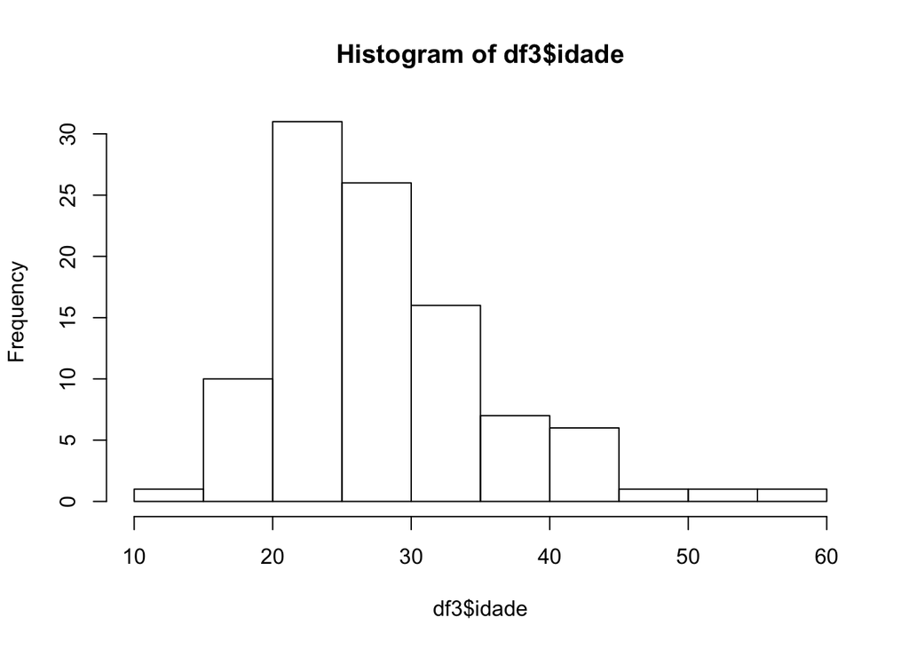

```r
hist(df3$idade)
```

#### imc

```r
df3 %>%
  summarise(
    media = round(mean(imc),2),
    dp = round(sd(imc),2),
    mediana = median(imc),
    iqr = IQR(imc)
  ) %>%
  kable() %>%
  kable_styling()
```

| media | dp | mediana | iqr |
| --- | --- | --- | --- |
| 25.79 | 4.7 | 24.6 | 5.675 |

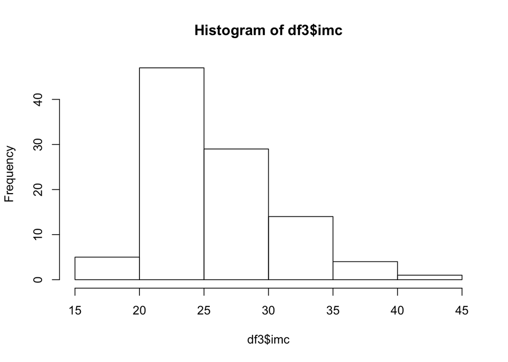

```r
hist(df3$imc)
```

#### experiência

```r
df3 %>%
  summarise(
    media = round(mean(experiencia, na.rm = T),2),
    dp = round(sd(experiencia, na.rm = T),2),
    mediana = median(experiencia, na.rm = T),
    iqr = IQR(experiencia, na.rm = T)
  ) %>%
  kable() %>%
  kable_styling()
```

| media | dp | mediana | iqr |
| --- | --- | --- | --- |
| 94.51 | 119.61 | 62.5 | 101 |

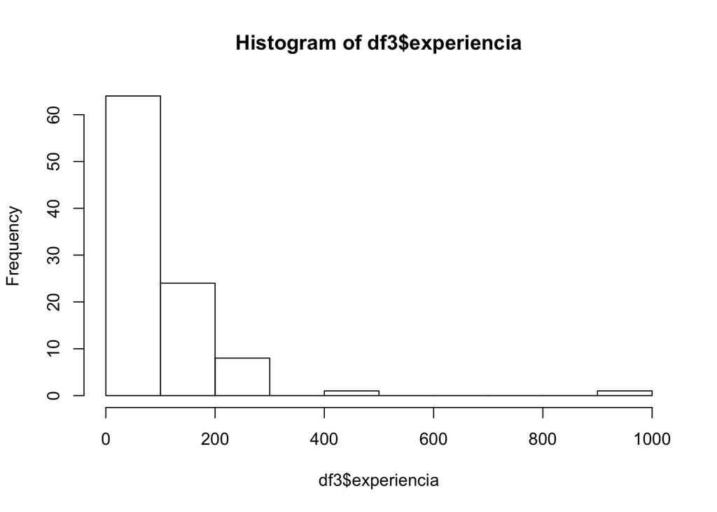

```r
hist(df3$experiencia)
```

#### horas na semana

```r
df3 %>%
  summarise(
    media = round(mean(horas_por_semana, na.rm = T),2),
    dp = round(sd(horas_por_semana, na.rm = T),2),
    mediana = median(horas_por_semana, na.rm = T),
    iqr = IQR(horas_por_semana, na.rm = T)
  ) %>%
  kable() %>%
  kable_styling()
```

| media | dp | mediana | iqr |
| --- | --- | --- | --- |
| 7.77 | 6.65 | 6 | 7 |

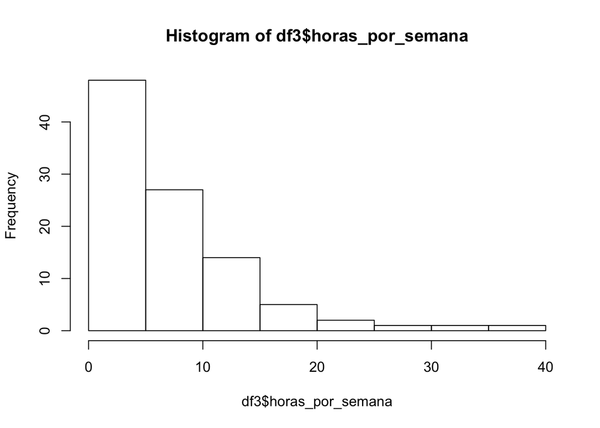

```r
hist(df3$horas_por_semana)
```

#### sexo

```r
df3 %>%
  group_by(sexo) %>%
  summarise(frequência = n()) %>%
  mutate(proporção = paste(frequência/sum(frequência)*100, "%")) %>%
  kable() %>%
  kable_styling()
```

| sexo | frequência | proporção |
| --- | --- | --- |
| Feminino | 36 | 36 % |
| Masculino | 64 | 64 % |

#### escolaridade

```r
df3 %>%
  group_by(escolaridade) %>%
  summarise(frequência = n()) %>%
  mutate(proporção = paste( frequência/sum(frequência)*100, '%')) %>%
  kable() %>%
  kable_styling()
```

| escolaridade | frequência | proporção |
| --- | --- | --- |
| Ensino fundamental completo | 1 | 1 % |
| Ensino medio completo | 21 | 21 % |
| Ensino medio incompleto | 4 | 4 % |
| Graduação completa | 28 | 28 % |
| Graduação incompleta | 32 | 32 % |
| Pos-graduação completa | 10 | 10 % |
| Pos-graduação incompleta | 4 | 4 % |

#### lesão no ultimo ano

```r
df3 %>%
  group_by(lesao_no_ultimo_ano) %>%
  summarise(frequência = n()) %>%
  mutate(proporção = paste(frequência/sum(frequência)*100, "%")) %>%
  kable() %>%
  kable_styling()
```

| lesao_no_ultimo_ano | frequência | proporção |
| --- | --- | --- |
| Você está afastado do esporte | 39 | 39 % |
| Você está participando de forma reduzida | 31 | 31 % |
| Você está treinando normalmente | 30 | 30 % |

#### esporte

```r
df3 %>%
  group_by(esporte) %>%
  summarise(frequência = n()) %>%
  mutate(proporção = paste(frequência/sum(frequência)*100, "%")) %>%
  kable() %>%
  kable_styling()
```

| esporte | frequência | proporção |
| --- | --- | --- |
| Atletismo | 1 | 1 % |
| Basquete | 5 | 5 % |
| Corrida | 2 | 2 % |
| Fisiculturismo | 1 | 1 % |
| Futebol | 21 | 21 % |
| Futebol Americano | 20 | 20 % |
| Futsal | 7 | 7 % |
| Ginástica Artística | 1 | 1 % |
| Handebol | 5 | 5 % |
| Jiu-jitsu | 2 | 2 % |
| Judô | 1 | 1 % |
| Marcha atletica | 1 | 1 % |
| Muay thai | 2 | 2 % |
| Musculação | 1 | 1 % |
| Natação | 2 | 2 % |
| Powerliftting | 1 | 1 % |
| Rugby | 12 | 12 % |
| Taekwondo | 5 | 5 % |
| Tenis | 1 | 1 % |
| Triathlon | 2 | 2 % |
| Ultramaratona | 1 | 1 % |
| Voleibol | 2 | 2 % |
| NA | 4 | 4 % |

#### tipo de esporte

```r
df3 %>%
  group_by(tipo_esporte) %>%
  summarise(frequência = n()) %>%
  mutate(proporção = paste(frequência/sum(frequência)*100, "%")) %>%
  kable() %>%
  kable_styling()
```

| tipo_esporte | frequência | proporção |
| --- | --- | --- |
| Coletivo | 76 | 76 % |
| individual | 24 | 24 % |

#### renda

```r
df3 %>%
  group_by(renda) %>%
  summarise(frequência = n()) %>%
  mutate(proporção = paste(frequência/sum(frequência)*100, "%")) %>%
  kable() %>%
  kable_styling()
```

| renda | frequência | proporção |
| --- | --- | --- |
| Não recebo renda pelo esporte | 85 | 85 % |
| Perdi após a lesão | 5 | 5 % |
| Sim, ministério do esporte | 1 | 1 % |
| Sim, pelo clube/grupo que participo | 8 | 8 % |
| Sim, por patrocinador | 1 | 1 % |

#### vezes por semana

```r
df3 %>%
  group_by(vezes_por_semana) %>%
  summarise(frequência = n()) %>%
  mutate(proporção = paste(frequência/sum(frequência)*100, "%")) %>%
  kable() %>%
  kable_styling()
```

| vezes_por_semana | frequência | proporção |
| --- | --- | --- |
| 1 vez por semana | 7 | 7 % |
| 2 vezes por semana | 12 | 12 % |
| 3 vezes por semana | 30 | 30 % |
| 4 vezes por semana | 12 | 12 % |
| 5 vezes por semana | 12 | 12 % |
| 6 vezes por semana | 14 | 14 % |
| Mais do que 6 vezes por semana | 9 | 9 % |
| NA | 4 | 4 % |

#### outro esporte

```r
df3 %>%
  group_by(outro_esporte) %>%
  summarise(frequência = n()) %>%
  mutate(proporção = paste(frequência/sum(frequência)*100, "%")) %>%
  kable() %>%
  kable_styling()
```

| outro_esporte | frequência | proporção |
| --- | --- | --- |
| Não | 59 | 59 % |
| Sim | 41 | 41 % |

#### região do corpo

```r
df4 <- df %>%
  select(regiao = qual_regiao_do_corpo_e_sua_queixa_lesao_atual) %>%
  separate(col = regiao, into = c("q1","q2","q3","q4","q5","q6","q7","q8"), sep = ", ") %>%
  gather(regiao) %>%
  select(value) %>%
  filter(complete.cases(value))

df4 %>%
  select(parte_do_corpo = value) %>%
  group_by(parte_do_corpo) %>%
  summarise(frequência = n()) %>%
  arrange(desc(frequência)) %>%
  mutate(
    propoção = paste(round((frequência/sum(frequência)*100), 1), "%")
  ) %>%
  kable() %>%
  kable_styling()
```

| parte_do_corpo | frequência | propoção |
| --- | --- | --- |
| Joelho | 55 | 39 % |
| Tornozelo | 18 | 12.8 % |
| Ombro | 15 | 10.6 % |
| Lombar | 12 | 8.5 % |
| Quadril | 10 | 7.1 % |
| Coxa | 5 | 3.5 % |
| Pé | 5 | 3.5 % |
| Perna | 5 | 3.5 % |
| Pescoço | 5 | 3.5 % |
| Mão | 4 | 2.8 % |
| Braço | 2 | 1.4 % |
| Cotovelo | 2 | 1.4 % |
| Torácica/Tronco | 2 | 1.4 % |
| Antebraço | 1 | 0.7 % |

## Limpando os questionários

### afaq

```r
df_afaq <- df %>%
  select(
    afaq_ =  eu_nunca_mais_serei_capaz_de_jogar_praticar_meu_esporte_como_antes_desta_lesao:quando_a_minha_dor_esta_intensa_eu_me_preocupo_que_a_minha_lesao_seja_muito_seria
  ) %>%
  mutate(
    afaq_1 = case_when(
      afaq_1 == "Discordo"               ~ 1,
      afaq_1 == "Concordo Pouco"         ~ 2,
      afaq_1 == "Concordo moderadamente" ~ 3,
      afaq_1 == "Concordo Bastante"      ~ 4,
      afaq_1 == "Concordo Totalmente"    ~ 5
    ),

    afaq_2 = case_when(
      afaq_2 == "Discordo"               ~ 1,
      afaq_2 == "Concordo Pouco"         ~ 2,
      afaq_2 == "Concordo moderadamente" ~ 3,
      afaq_2 == "Concordo Bastante"      ~ 4,
      afaq_2 == "Concordo Totalmente"    ~ 5
    ),

     afaq_3 = case_when(
      afaq_3 == "Discordo"               ~ 1,
      afaq_3 == "Concordo Pouco"         ~ 2,
      afaq_3 == "Concordo moderadamente" ~ 3,
      afaq_3 == "Concordo Bastante"      ~ 4,
      afaq_3 == "Concordo Totalmente"    ~ 5
    ),

     afaq_4 = case_when(
      afaq_4 == "Discordo"               ~ 1,
      afaq_4 == "Concordo Pouco"         ~ 2,
      afaq_4 == "Concordo moderadamente" ~ 3,
      afaq_4 == "Concordo Bastante"      ~ 4,
      afaq_4 == "Concordo Totalmente"    ~ 5
    ),

     afaq_5 = case_when(
      afaq_5 == "Discordo"               ~ 1,
      afaq_5 == "Concordo Pouco"         ~ 2,
      afaq_5 == "Concordo moderadamente" ~ 3,
      afaq_5 == "Concordo Bastante"      ~ 4,
      afaq_5 == "Concordo Totalmente"    ~ 5
    ),

     afaq_6 = case_when(
      afaq_6 == "Discordo"               ~ 1,
      afaq_6 == "Concordo Pouco"         ~ 2,
      afaq_6 == "Concordo moderadamente" ~ 3,
      afaq_6 == "Concordo Bastante"      ~ 4,
      afaq_6 == "Concordo Totalmente"    ~ 5
    ),

     afaq_7 = case_when(
      afaq_7 == "Discordo"               ~ 1,
      afaq_7 == "Concordo Pouco"         ~ 2,
      afaq_7 == "Concordo moderadamente" ~ 3,
      afaq_7 == "Concordo Bastante"      ~ 4,
      afaq_7 == "Concordo Totalmente"    ~ 5
    ),

     afaq_8 = case_when(
      afaq_8 == "Discordo"               ~ 1,
      afaq_8 == "Concordo Pouco"         ~ 2,
      afaq_8 == "Concordo moderadamente" ~ 3,
      afaq_8 == "Concordo Bastante"      ~ 4,
      afaq_8 == "Concordo Totalmente"    ~ 5
    ),

     afaq_9 = case_when(
      afaq_9 == "Discordo"               ~ 1,
      afaq_9 == "Concordo Pouco"         ~ 2,
      afaq_9 == "Concordo moderadamente" ~ 3,
      afaq_9 == "Concordo Bastante"      ~ 4,
      afaq_9 == "Concordo Totalmente"    ~ 5
    ),

     afaq_10 = case_when(
      afaq_10 == "Discordo"               ~ 1,
      afaq_10 == "Concordo Pouco"         ~ 2,
      afaq_10 == "Concordo moderadamente" ~ 3,
      afaq_10 == "Concordo Bastante"      ~ 4,
      afaq_10 == "Concordo Totalmente"    ~ 5
    ),
  )
```

### pcs

```r
df_pcs <- df %>%
  select(
    pcs_ =  a_preocupacao_durante_todo_o_tempo_com_a_duracao_da_dor_e:a_preocupacao_que_alguma_coisa_ruim_pode_acontecer_por_causa_da_dor_e
  )%>%
  mutate(
    pcs_1 = case_when(
      pcs_1 == "0-MINIMA"        ~ 1,
      pcs_1 == "1-LEVE"          ~ 2,
      pcs_1 == "2-MODERADO"      ~ 3,
      pcs_1 == "3-INTENSA"       ~ 4,
      pcs_1 == "4-MUITO INTENSA" ~ 5
    ),
  pcs_2 = case_when(
      pcs_2 == "0-MINIMA"        ~ 1,
      pcs_2 == "1-LEVE"          ~ 2,
      pcs_2 == "2-MODERADO"      ~ 3,
      pcs_2 == "3-INTENSA"       ~ 4,
      pcs_2 == "4-MUITO INTENSA" ~ 5
    ),
  pcs_3 = case_when(
      pcs_3 == "0-MINIMA"        ~ 1,
      pcs_3 == "1-LEVE"          ~ 2,
      pcs_3 == "2-MODERADO"      ~ 3,
      pcs_3 == "3-INTENSA"       ~ 4,
      pcs_3 == "4-MUITO INTENSA" ~ 5
    ),
  pcs_4 = case_when(
      pcs_4 == "0-MINIMA"        ~ 1,
      pcs_4 == "1-LEVE"          ~ 2,
      pcs_4 == "2-MODERADO"      ~ 3,
      pcs_4 == "3-INTENSA"       ~ 4,
      pcs_4 == "4-MUITO INTENSA" ~ 5
    ),
  pcs_5 = case_when(
      pcs_5 == "0-MINIMA"        ~ 1,
      pcs_5 == "1-LEVE"          ~ 2,
      pcs_5 == "2-MODERADO"      ~ 3,
      pcs_5 == "3-INTENSA"       ~ 4,
      pcs_5 == "4-MUITO INTENSA" ~ 5
    ),
  pcs_6 = case_when(
      pcs_6 == "0-MINIMA"        ~ 1,
      pcs_6 == "1-LEVE"          ~ 2,
      pcs_6 == "2-MODERADO"      ~ 3,
      pcs_6 == "3-INTENSA"       ~ 4,
      pcs_6 == "4-MUITO INTENSA" ~ 5
    ),
  pcs_7 = case_when(
      pcs_7 == "0-MINIMA"        ~ 1,
      pcs_7 == "1-LEVE"          ~ 2,
      pcs_7 == "2-MODERADO"      ~ 3,
      pcs_7 == "3-INTENSA"       ~ 4,
      pcs_7 == "4-MUITO INTENSA" ~ 5
    ),
  pcs_8 = case_when(
      pcs_8 == "0-MINIMA"        ~ 1,
      pcs_8 == "1-LEVE"          ~ 2,
      pcs_8 == "2-MODERADO"      ~ 3,
      pcs_8 == "3-INTENSA"       ~ 4,
      pcs_8 == "4-MUITO INTENSA" ~ 5
    ),
  pcs_9 = case_when(
      pcs_9 == "0-MINIMA"        ~ 1,
      pcs_9 == "1-LEVE"          ~ 2,
      pcs_9 == "2-MODERADO"      ~ 3,
      pcs_9 == "3-INTENSA"       ~ 4,
      pcs_9 == "4-MUITO INTENSA" ~ 5
    ),
  pcs_10 = case_when(
      pcs_10 == "0-MINIMA"        ~ 1,
      pcs_10 == "1-LEVE"          ~ 2,
      pcs_10 == "2-MODERADO"      ~ 3,
      pcs_10 == "3-INTENSA"       ~ 4,
      pcs_10 == "4-MUITO INTENSA" ~ 5
    ),
  pcs_11 = case_when(
      pcs_11 == "0-MINIMA"        ~ 1,
      pcs_11 == "1-LEVE"          ~ 2,
      pcs_11 == "2-MODERADO"      ~ 3,
      pcs_11 == "3-INTENSA"       ~ 4,
      pcs_11 == "4-MUITO INTENSA" ~ 5
    ),
  pcs_12 = case_when(
      pcs_12 == "0-MINIMA"        ~ 1,
      pcs_12 == "1-LEVE"          ~ 2,
      pcs_12 == "2-MODERADO"      ~ 3,
      pcs_12 == "3-INTENSA"       ~ 4,
      pcs_12 == "4-MUITO INTENSA" ~ 5
    ),
  pcs_13 = case_when(
      pcs_13 == "0-MINIMA"        ~ 1,
      pcs_13 == "1-LEVE"          ~ 2,
      pcs_13 == "2-MODERADO"      ~ 3,
      pcs_13 == "3-INTENSA"       ~ 4,
      pcs_13 == "4-MUITO INTENSA" ~ 5
    ),
  )
```

### tampa

```r
df_tampa <- df %>%
  select(
    tampa_ =  eu_tenho_medo_que_eu_possa_me_machucar_se_eu_fizer_exercicios:ninguem_deveria_fazer_exercicios_quando_esta_com_dor
  ) %>%
  mutate(
    tampa_1 = case_when(
      tampa_1 == "DISCORDO TOTALMENTE"   ~ 1,
      tampa_1 == "DISCORDO PARCIALMENTE" ~ 2,
      tampa_1 == "CONCORDO PARCIALMENTE" ~ 3,
      tampa_1 == "CONCORDO TOTALMENTE"   ~ 4
    ),
    tampa_2 = case_when(
      tampa_2 == "DISCORDO TOTALMENTE"   ~ 1,
      tampa_2 == "DISCORDO PARCIALMENTE" ~ 2,
      tampa_2 == "CONCORDO PARCIALMENTE" ~ 3,
      tampa_2 == "CONCORDO TOTALMENTE"   ~ 4
    ),
    tampa_3 = case_when(
      tampa_3 == "DISCORDO TOTALMENTE"   ~ 1,
      tampa_3 == "DISCORDO PARCIALMENTE" ~ 2,
      tampa_3 == "CONCORDO PARCIALMENTE" ~ 3,
      tampa_3 == "CONCORDO TOTALMENTE"   ~ 4
    ),
    tampa_4 = case_when( #invertido
      tampa_4 == "DISCORDO TOTALMENTE"   ~ 4,
      tampa_4 == "DISCORDO PARCIALMENTE" ~ 3,
      tampa_4 == "CONCORDO PARCIALMENTE" ~ 2,
      tampa_4 == "CONCORDO TOTALMENTE"   ~ 1
    ),
    tampa_5 = case_when(
      tampa_5 == "DISCORDO TOTALMENTE"   ~ 1,
      tampa_5 == "DISCORDO PARCIALMENTE" ~ 2,
      tampa_5 == "CONCORDO PARCIALMENTE" ~ 3,
      tampa_5 == "CONCORDO TOTALMENTE"   ~ 4
    ),
    tampa_6 = case_when(
      tampa_6 == "DISCORDO TOTALMENTE"   ~ 1,
      tampa_6 == "DISCORDO PARCIALMENTE" ~ 2,
      tampa_6 == "CONCORDO PARCIALMENTE" ~ 3,
      tampa_6 == "CONCORDO TOTALMENTE"   ~ 4
    ),
    tampa_7 = case_when(
      tampa_7 == "DISCORDO TOTALMENTE"   ~ 1,
      tampa_7 == "DISCORDO PARCIALMENTE" ~ 2,
      tampa_7 == "CONCORDO PARCIALMENTE" ~ 3,
      tampa_7 == "CONCORDO TOTALMENTE"   ~ 4
    ),
    tampa_8 = case_when(#invertido
      tampa_8 == "DISCORDO TOTALMENTE"   ~ 4,
      tampa_8 == "DISCORDO PARCIALMENTE" ~ 3,
      tampa_8 == "CONCORDO PARCIALMENTE" ~ 2,
      tampa_8 == "CONCORDO TOTALMENTE"   ~ 1
    ),
    tampa_9 = case_when(
      tampa_9 == "DISCORDO TOTALMENTE"   ~ 1,
      tampa_9 == "DISCORDO PARCIALMENTE" ~ 2,
      tampa_9 == "CONCORDO PARCIALMENTE" ~ 3,
      tampa_9 == "CONCORDO TOTALMENTE"   ~ 4
    ),
    tampa_10 = case_when(
      tampa_10 == "DISCORDO TOTALMENTE"   ~ 1,
      tampa_10 == "DISCORDO PARCIALMENTE" ~ 2,
      tampa_10 == "CONCORDO PARCIALMENTE" ~ 3,
      tampa_10 == "CONCORDO TOTALMENTE"   ~ 4
    ),
    tampa_11 = case_when(
      tampa_11 == "DISCORDO TOTALMENTE"   ~ 1,
      tampa_11 == "DISCORDO PARCIALMENTE" ~ 2,
      tampa_11 == "CONCORDO PARCIALMENTE" ~ 3,
      tampa_11 == "CONCORDO TOTALMENTE"   ~ 4
    ),
    tampa_12 = case_when( #invertido
      tampa_12 == "DISCORDO TOTALMENTE"   ~ 4,
      tampa_12 == "DISCORDO PARCIALMENTE" ~ 3,
      tampa_12 == "CONCORDO PARCIALMENTE" ~ 2,
      tampa_12 == "CONCORDO TOTALMENTE"   ~ 1
    ),
    tampa_13 = case_when(
      tampa_13 == "DISCORDO TOTALMENTE"   ~ 1,
      tampa_13 == "DISCORDO PARCIALMENTE" ~ 2,
      tampa_13 == "CONCORDO PARCIALMENTE" ~ 3,
      tampa_13 == "CONCORDO TOTALMENTE"   ~ 4
    ),
    tampa_14 = case_when(
      tampa_14 == "DISCORDO TOTALMENTE"   ~ 1,
      tampa_14 == "DISCORDO PARCIALMENTE" ~ 2,
      tampa_14 == "CONCORDO PARCIALMENTE" ~ 3,
      tampa_14 == "CONCORDO TOTALMENTE"   ~ 4
    ),
    tampa_15 = case_when(
      tampa_15 == "DISCORDO TOTALMENTE"   ~ 1,
      tampa_15 == "DISCORDO PARCIALMENTE" ~ 2,
      tampa_15 == "CONCORDO PARCIALMENTE" ~ 3,
      tampa_15 == "CONCORDO TOTALMENTE"   ~ 4
    ),
    tampa_16 = case_when( #invertido
      tampa_16 == "DISCORDO TOTALMENTE"   ~ 4,
      tampa_16 == "DISCORDO PARCIALMENTE" ~ 3,
      tampa_16 == "CONCORDO PARCIALMENTE" ~ 2,
      tampa_16 == "CONCORDO TOTALMENTE"   ~ 1
    ),
    tampa_17 = case_when(
      tampa_17 == "DISCORDO TOTALMENTE"   ~ 1,
      tampa_17 == "DISCORDO PARCIALMENTE" ~ 2,
      tampa_17 == "CONCORDO PARCIALMENTE" ~ 3,
      tampa_17 == "CONCORDO TOTALMENTE"   ~ 4
    ),
  )
```

### tampa invertido

```r
df_tampa_invert <- df %>%
  select(
    tampa_ =  eu_tenho_medo_que_eu_possa_me_machucar_se_eu_fizer_exercicios:ninguem_deveria_fazer_exercicios_quando_esta_com_dor
  ) %>%
  mutate(
    tampa_1 = case_when(
      tampa_1 == "DISCORDO TOTALMENTE"   ~ 1,
      tampa_1 == "DISCORDO PARCIALMENTE" ~ 2,
      tampa_1 == "CONCORDO PARCIALMENTE" ~ 3,
      tampa_1 == "CONCORDO TOTALMENTE"   ~ 4
    ),
    tampa_2 = case_when(
      tampa_2 == "DISCORDO TOTALMENTE"   ~ 1,
      tampa_2 == "DISCORDO PARCIALMENTE" ~ 2,
      tampa_2 == "CONCORDO PARCIALMENTE" ~ 3,
      tampa_2 == "CONCORDO TOTALMENTE"   ~ 4
    ),
    tampa_3 = case_when(
      tampa_3 == "DISCORDO TOTALMENTE"   ~ 1,
      tampa_3 == "DISCORDO PARCIALMENTE" ~ 2,
      tampa_3 == "CONCORDO PARCIALMENTE" ~ 3,
      tampa_3 == "CONCORDO TOTALMENTE"   ~ 4
    ),
    tampa_4 = case_when(
      tampa_4 == "DISCORDO TOTALMENTE"   ~ 1,
      tampa_4 == "DISCORDO PARCIALMENTE" ~ 2,
      tampa_4 == "CONCORDO PARCIALMENTE" ~ 3,
      tampa_4 == "CONCORDO TOTALMENTE"   ~ 4
    ),
    tampa_5 = case_when(
      tampa_5 == "DISCORDO TOTALMENTE"   ~ 1,
      tampa_5 == "DISCORDO PARCIALMENTE" ~ 2,
      tampa_5 == "CONCORDO PARCIALMENTE" ~ 3,
      tampa_5 == "CONCORDO TOTALMENTE"   ~ 4
    ),
    tampa_6 = case_when(
      tampa_6 == "DISCORDO TOTALMENTE"   ~ 1,
      tampa_6 == "DISCORDO PARCIALMENTE" ~ 2,
      tampa_6 == "CONCORDO PARCIALMENTE" ~ 3,
      tampa_6 == "CONCORDO TOTALMENTE"   ~ 4
    ),
    tampa_7 = case_when(
      tampa_7 == "DISCORDO TOTALMENTE"   ~ 1,
      tampa_7 == "DISCORDO PARCIALMENTE" ~ 2,
      tampa_7 == "CONCORDO PARCIALMENTE" ~ 3,
      tampa_7 == "CONCORDO TOTALMENTE"   ~ 4
    ),
    tampa_8 = case_when(
      tampa_8 == "DISCORDO TOTALMENTE"   ~ 1,
      tampa_8 == "DISCORDO PARCIALMENTE" ~ 2,
      tampa_8 == "CONCORDO PARCIALMENTE" ~ 3,
      tampa_8 == "CONCORDO TOTALMENTE"   ~ 4
    ),
    tampa_9 = case_when(
      tampa_9 == "DISCORDO TOTALMENTE"   ~ 1,
      tampa_9 == "DISCORDO PARCIALMENTE" ~ 2,
      tampa_9 == "CONCORDO PARCIALMENTE" ~ 3,
      tampa_9 == "CONCORDO TOTALMENTE"   ~ 4
    ),
    tampa_10 = case_when(
      tampa_10 == "DISCORDO TOTALMENTE"   ~ 1,
      tampa_10 == "DISCORDO PARCIALMENTE" ~ 2,
      tampa_10 == "CONCORDO PARCIALMENTE" ~ 3,
      tampa_10 == "CONCORDO TOTALMENTE"   ~ 4
    ),
    tampa_11 = case_when(
      tampa_11 == "DISCORDO TOTALMENTE"   ~ 1,
      tampa_11 == "DISCORDO PARCIALMENTE" ~ 2,
      tampa_11 == "CONCORDO PARCIALMENTE" ~ 3,
      tampa_11 == "CONCORDO TOTALMENTE"   ~ 4
    ),
    tampa_12 = case_when(
      tampa_12 == "DISCORDO TOTALMENTE"   ~ 1,
      tampa_12 == "DISCORDO PARCIALMENTE" ~ 2,
      tampa_12 == "CONCORDO PARCIALMENTE" ~ 3,
      tampa_12 == "CONCORDO TOTALMENTE"   ~ 4
    ),
    tampa_13 = case_when(
      tampa_13 == "DISCORDO TOTALMENTE"   ~ 1,
      tampa_13 == "DISCORDO PARCIALMENTE" ~ 2,
      tampa_13 == "CONCORDO PARCIALMENTE" ~ 3,
      tampa_13 == "CONCORDO TOTALMENTE"   ~ 4
    ),
    tampa_14 = case_when(
      tampa_14 == "DISCORDO TOTALMENTE"   ~ 1,
      tampa_14 == "DISCORDO PARCIALMENTE" ~ 2,
      tampa_14 == "CONCORDO PARCIALMENTE" ~ 3,
      tampa_14 == "CONCORDO TOTALMENTE"   ~ 4
    ),
    tampa_15 = case_when(
      tampa_15 == "DISCORDO TOTALMENTE"   ~ 1,
      tampa_15 == "DISCORDO PARCIALMENTE" ~ 2,
      tampa_15 == "CONCORDO PARCIALMENTE" ~ 3,
      tampa_15 == "CONCORDO TOTALMENTE"   ~ 4
    ),
    tampa_16 = case_when(
      tampa_16 == "DISCORDO TOTALMENTE"   ~ 1,
      tampa_16 == "DISCORDO PARCIALMENTE" ~ 2,
      tampa_16 == "CONCORDO PARCIALMENTE" ~ 3,
      tampa_16 == "CONCORDO TOTALMENTE"   ~ 4
    ),
    tampa_17 = case_when(
      tampa_17 == "DISCORDO TOTALMENTE"   ~ 1,
      tampa_17 == "DISCORDO PARCIALMENTE" ~ 2,
      tampa_17 == "CONCORDO PARCIALMENTE" ~ 3,
      tampa_17 == "CONCORDO TOTALMENTE"   ~ 4
    ),
  )
```

### fabq

```r
df_fabq <- df %>%
  select(
    fabq_ =  fabqQ1:fabqQ10
  ) %>%
  mutate(
    fabq_1 = case_when(
      fabq_1 == "0" ~ 1,
      fabq_1 == "1" ~ 2,
      fabq_1 == "2" ~ 3,
      fabq_1 == "3" ~ 4,
      fabq_1 == "4" ~ 5,
      fabq_1 == "5" ~ 6,
      fabq_1 == "6" ~ 7
    ),
    fabq_2 = case_when(
      fabq_2 == "0" ~ 1,
      fabq_2 == "1" ~ 2,
      fabq_2 == "2" ~ 3,
      fabq_2 == "3" ~ 4,
      fabq_2 == "4" ~ 5,
      fabq_2 == "5" ~ 6,
      fabq_2 == "6" ~ 7
    ),
    fabq_3 = case_when(
      fabq_3 == "0" ~ 1,
      fabq_3 == "1" ~ 2,
      fabq_3 == "2" ~ 3,
      fabq_3 == "3" ~ 4,
      fabq_3 == "4" ~ 5,
      fabq_3 == "5" ~ 6,
      fabq_3 == "6" ~ 7
    ),
    fabq_4 = case_when(
      fabq_4 == "0" ~ 1,
      fabq_4 == "1" ~ 2,
      fabq_4 == "2" ~ 3,
      fabq_4 == "3" ~ 4,
      fabq_4 == "4" ~ 5,
      fabq_4 == "5" ~ 6,
      fabq_4 == "6" ~ 7
    ),
    fabq_5 = case_when(
      fabq_5 == "0" ~ 1,
      fabq_5 == "1" ~ 2,
      fabq_5 == "2" ~ 3,
      fabq_5 == "3" ~ 4,
      fabq_5 == "4" ~ 5,
      fabq_5 == "5" ~ 6,
      fabq_5 == "6" ~ 7
    ),
    fabq_6 = case_when(
      fabq_6 == "0" ~ 1,
      fabq_6 == "1" ~ 2,
      fabq_6 == "2" ~ 3,
      fabq_6 == "3" ~ 4,
      fabq_6 == "4" ~ 5,
      fabq_6 == "5" ~ 6,
      fabq_6 == "6" ~ 7
    ),
    fabq_7 = case_when(
      fabq_7 == "0" ~ 1,
      fabq_7 == "1" ~ 2,
      fabq_7 == "2" ~ 3,
      fabq_7 == "3" ~ 4,
      fabq_7 == "4" ~ 5,
      fabq_7 == "5" ~ 6,
      fabq_7 == "6" ~ 7
    ),
    fabq_8 = case_when(
      fabq_8 == "0" ~ 1,
      fabq_8 == "1" ~ 2,
      fabq_8 == "2" ~ 3,
      fabq_8 == "3" ~ 4,
      fabq_8 == "4" ~ 5,
      fabq_8 == "5" ~ 6,
      fabq_8 == "6" ~ 7
    ),
    fabq_9 = case_when(
      fabq_9 == "0" ~ 1,
      fabq_9 == "1" ~ 2,
      fabq_9 == "2" ~ 3,
      fabq_9 == "3" ~ 4,
      fabq_9 == "4" ~ 5,
      fabq_9 == "5" ~ 6,
      fabq_9 == "6" ~ 7
    ),
    fabq_10 = case_when(
      fabq_10 == "0" ~ 1,
      fabq_10 == "1" ~ 2,
      fabq_10 == "2" ~ 3,
      fabq_10 == "3" ~ 4,
      fabq_10 == "4" ~ 5,
      fabq_10 == "5" ~ 6,
      fabq_10 == "6" ~ 7
    ),
    fabq_11 = case_when(
      fabq_11 == "0" ~ 1,
      fabq_11 == "1" ~ 2,
      fabq_11 == "2" ~ 3,
      fabq_11 == "3" ~ 4,
      fabq_11 == "4" ~ 5,
      fabq_11 == "5" ~ 6,
      fabq_11 == "6" ~ 7
    ),
    fabq_12 = case_when(
      fabq_12 == "0" ~ 1,
      fabq_12 == "1" ~ 2,
      fabq_12 == "2" ~ 3,
      fabq_12 == "3" ~ 4,
      fabq_12 == "4" ~ 5,
      fabq_12 == "5" ~ 6,
      fabq_12 == "6" ~ 7
    ),
    fabq_13 = case_when(
      fabq_13 == "0" ~ 1,
      fabq_13 == "1" ~ 2,
      fabq_13 == "2" ~ 3,
      fabq_13 == "3" ~ 4,
      fabq_13 == "4" ~ 5,
      fabq_13 == "5" ~ 6,
      fabq_13 == "6" ~ 7
    ),
    fabq_14 = case_when(
      fabq_14 == "0" ~ 1,
      fabq_14 == "1" ~ 2,
      fabq_14 == "2" ~ 3,
      fabq_14 == "3" ~ 4,
      fabq_14 == "4" ~ 5,
      fabq_14 == "5" ~ 6,
      fabq_14 == "6" ~ 7
    ),
    fabq_15 = case_when(
      fabq_15 == "0" ~ 1,
      fabq_15 == "1" ~ 2,
      fabq_15 == "2" ~ 3,
      fabq_15 == "3" ~ 4,
      fabq_15 == "4" ~ 5,
      fabq_15 == "5" ~ 6,
      fabq_15 == "6" ~ 7
    ),
    fabq_16 = case_when(
      fabq_16 == "0" ~ 1,
      fabq_16 == "1" ~ 2,
      fabq_16 == "2" ~ 3,
      fabq_16 == "3" ~ 4,
      fabq_16 == "4" ~ 5,
      fabq_16 == "5" ~ 6,
      fabq_16 == "6" ~ 7
    ),
  )
```

## Internal Consistency

### alfa de Cronbach

####afaq

```r
alpha_afaq <- alpha(df_afaq)
alpha_afaq
```

```
##
## Reliability analysis
## Call: alpha(x = df_afaq)
##
##   raw_alpha std.alpha G6(smc) average_r S/N   ase mean   sd median_r
##       0.81       0.8    0.82      0.29 4.1 0.027  2.3 0.81     0.28
##
##  lower alpha upper     95% confidence boundaries
## 0.76 0.81 0.86
##
##  Reliability if an item is dropped:
##         raw_alpha std.alpha G6(smc) average_r S/N alpha se var.r med.r
## afaq_1       0.81      0.80    0.81      0.31 4.0    0.028 0.020  0.30
## afaq_2       0.80      0.80    0.81      0.30 3.9    0.028 0.021  0.28
## afaq_3       0.81      0.80    0.82      0.31 4.0    0.027 0.024  0.30
## afaq_4       0.82      0.81    0.82      0.32 4.3    0.027 0.017  0.30
## afaq_5       0.78      0.77    0.79      0.27 3.4    0.032 0.024  0.25
## afaq_6       0.78      0.78    0.79      0.28 3.5    0.031 0.018  0.27
## afaq_7       0.78      0.77    0.80      0.28 3.4    0.031 0.024  0.26
## afaq_8       0.77      0.77    0.78      0.27 3.3    0.033 0.018  0.27
## afaq_9       0.79      0.78    0.80      0.29 3.6    0.030 0.019  0.28
## afaq_10      0.79      0.78    0.80      0.28 3.5    0.031 0.021  0.28
##
##  Item statistics
##           n raw.r std.r r.cor r.drop mean  sd
## afaq_1  100  0.47  0.50  0.43   0.36  1.7 1.1
## afaq_2  100  0.50  0.53  0.46   0.39  1.8 1.1
## afaq_3  100  0.48  0.49  0.39   0.35  1.9 1.3
## afaq_4  100  0.37  0.39  0.28   0.24  1.6 1.1
## afaq_5  100  0.71  0.71  0.68   0.60  2.9 1.5
## afaq_6  100  0.70  0.67  0.64   0.58  2.7 1.5
## afaq_7  100  0.68  0.69  0.64   0.58  2.2 1.3
## afaq_8  100  0.75  0.74  0.72   0.66  2.2 1.4
## afaq_9  100  0.65  0.63  0.59   0.53  3.3 1.5
## afaq_10 100  0.68  0.66  0.61   0.56  3.2 1.5
##
## Non missing response frequency for each item
##            1    2    3    4    5 miss
## afaq_1  0.64 0.17 0.10 0.06 0.03    0
## afaq_2  0.55 0.22 0.13 0.07 0.03    0
## afaq_3  0.56 0.20 0.08 0.09 0.07    0
## afaq_4  0.71 0.13 0.09 0.02 0.05    0
## afaq_5  0.24 0.22 0.16 0.16 0.22    0
## afaq_6  0.31 0.23 0.16 0.09 0.21    0
## afaq_7  0.40 0.24 0.18 0.11 0.07    0
## afaq_8  0.44 0.19 0.20 0.06 0.11    0
## afaq_9  0.14 0.23 0.18 0.12 0.33    0
## afaq_10 0.19 0.17 0.16 0.18 0.30    0
```

#### pcs

```r
alpha_pcs <- alpha(df_pcs)
alpha_pcs
```

```
##
## Reliability analysis
## Call: alpha(x = df_pcs)
##
##   raw_alpha std.alpha G6(smc) average_r S/N  ase mean   sd median_r
##       0.93      0.93    0.94       0.5  13 0.01  2.5 0.92     0.51
##
##  lower alpha upper     95% confidence boundaries
## 0.91 0.93 0.95
##
##  Reliability if an item is dropped:
##        raw_alpha std.alpha G6(smc) average_r S/N alpha se var.r med.r
## pcs_1       0.93      0.93    0.94      0.51  12   0.0109 0.019  0.51
## pcs_2       0.93      0.93    0.94      0.51  12   0.0107 0.019  0.54
## pcs_3       0.92      0.92    0.93      0.49  11   0.0116 0.018  0.48
## pcs_4       0.92      0.92    0.93      0.49  12   0.0114 0.019  0.47
## pcs_5       0.93      0.93    0.94      0.52  13   0.0104 0.016  0.55
## pcs_6       0.92      0.92    0.93      0.49  11   0.0117 0.018  0.48
## pcs_7       0.92      0.92    0.94      0.51  12   0.0109 0.018  0.53
## pcs_8       0.93      0.93    0.94      0.53  14   0.0099 0.013  0.55
## pcs_9       0.92      0.92    0.93      0.49  11   0.0117 0.018  0.47
## pcs_10      0.92      0.92    0.93      0.49  11   0.0118 0.017  0.47
## pcs_11      0.92      0.92    0.93      0.48  11   0.0118 0.017  0.48
## pcs_12      0.92      0.92    0.93      0.50  12   0.0111 0.018  0.51
## pcs_13      0.92      0.92    0.93      0.49  12   0.0115 0.018  0.49
##
##  Item statistics
##          n raw.r std.r r.cor r.drop mean  sd
## pcs_1  100  0.67  0.68  0.64   0.62  2.7 1.1
## pcs_2  100  0.68  0.67  0.64   0.61  2.9 1.3
## pcs_3  100  0.81  0.81  0.80   0.76  2.2 1.3
## pcs_4  100  0.77  0.78  0.77   0.73  1.8 1.1
## pcs_5  100  0.56  0.57  0.52   0.49  1.7 1.1
## pcs_6  100  0.82  0.82  0.81   0.78  2.7 1.3
## pcs_7  100  0.69  0.69  0.66   0.63  2.6 1.2
## pcs_8  100  0.52  0.51  0.45   0.43  4.1 1.3
## pcs_9  100  0.82  0.82  0.81   0.78  2.3 1.3
## pcs_10 100  0.83  0.83  0.82   0.80  2.7 1.3
## pcs_11 100  0.84  0.84  0.84   0.81  2.4 1.2
## pcs_12 100  0.73  0.73  0.71   0.68  2.1 1.2
## pcs_13 100  0.80  0.79  0.78   0.75  2.5 1.3
##
## Non missing response frequency for each item
##           1    2    3    4    5 miss
## pcs_1  0.15 0.27 0.36 0.15 0.07    0
## pcs_2  0.22 0.18 0.21 0.27 0.12    0
## pcs_3  0.39 0.25 0.18 0.11 0.07    0
## pcs_4  0.55 0.20 0.16 0.06 0.03    0
## pcs_5  0.68 0.12 0.10 0.06 0.04    0
## pcs_6  0.23 0.22 0.25 0.18 0.12    0
## pcs_7  0.23 0.25 0.33 0.10 0.09    0
## pcs_8  0.08 0.06 0.13 0.14 0.59    0
## pcs_9  0.39 0.23 0.15 0.16 0.07    0
## pcs_10 0.20 0.29 0.21 0.17 0.13    0
## pcs_11 0.32 0.27 0.21 0.14 0.06    0
## pcs_12 0.46 0.23 0.14 0.13 0.04    0
## pcs_13 0.30 0.28 0.15 0.18 0.09    0
```

#### tampa

```r
alpha_tampa_invert <- alpha(df_tampa_invert)
```

```
## Some items ( tampa_8 ) were negatively correlated with the total scale and
## probably should be reversed.
## To do this, run the function again with the 'check.keys=TRUE' option
```

```r
alpha_tampa_invert
```

```
##
## Reliability analysis
## Call: alpha(x = df_tampa_invert)
##
##   raw_alpha std.alpha G6(smc) average_r S/N   ase mean   sd median_r
##       0.77      0.77    0.82      0.16 3.3 0.033  2.2 0.48     0.16
##
##  lower alpha upper     95% confidence boundaries
## 0.7 0.77 0.83
##
##  Reliability if an item is dropped:
##          raw_alpha std.alpha G6(smc) average_r S/N alpha se var.r med.r
## tampa_1       0.75      0.75    0.80      0.16 3.1    0.036 0.020  0.15
## tampa_2       0.76      0.76    0.80      0.16 3.1    0.035 0.020  0.16
## tampa_3       0.74      0.74    0.79      0.15 2.9    0.038 0.019  0.15
## tampa_4       0.77      0.77    0.81      0.18 3.4    0.032 0.020  0.17
## tampa_5       0.77      0.77    0.81      0.17 3.3    0.034 0.022  0.17
## tampa_6       0.75      0.75    0.79      0.16 2.9    0.037 0.021  0.14
## tampa_7       0.76      0.76    0.81      0.16 3.2    0.035 0.021  0.16
## tampa_8       0.78      0.78    0.82      0.18 3.6    0.032 0.018  0.17
## tampa_9       0.74      0.75    0.79      0.15 2.9    0.037 0.020  0.15
## tampa_10      0.76      0.76    0.80      0.16 3.1    0.035 0.020  0.15
## tampa_11      0.75      0.75    0.80      0.16 3.1    0.036 0.020  0.15
## tampa_12      0.77      0.77    0.81      0.17 3.3    0.033 0.021  0.17
## tampa_13      0.75      0.75    0.79      0.16 3.0    0.036 0.020  0.15
## tampa_14      0.75      0.75    0.80      0.16 3.1    0.035 0.021  0.16
## tampa_15      0.74      0.74    0.79      0.15 2.9    0.037 0.020  0.15
## tampa_16      0.77      0.77    0.82      0.18 3.4    0.033 0.021  0.17
## tampa_17      0.75      0.75    0.80      0.16 3.0    0.036 0.020  0.15
##
##  Item statistics
##            n raw.r std.r r.cor r.drop mean   sd
## tampa_1  100  0.51  0.50 0.477   0.40  2.5 1.11
## tampa_2  100  0.47  0.48 0.440   0.37  1.7 0.90
## tampa_3  100  0.65  0.65 0.642   0.57  2.2 1.10
## tampa_4  100  0.27  0.26 0.182   0.14  2.5 1.11
## tampa_5  100  0.35  0.36 0.271   0.23  1.9 1.00
## tampa_6  100  0.59  0.59 0.567   0.49  1.8 1.06
## tampa_7  100  0.44  0.44 0.387   0.33  2.5 1.03
## tampa_8  100  0.16  0.16 0.076   0.04  2.2 0.97
```

[output cut: 14 more lines]

```
## tampa_3  0.34 0.27 0.22 0.17    0
## tampa_4  0.26 0.23 0.28 0.23    0
## tampa_5  0.51 0.20 0.22 0.07    0
## tampa_6  0.56 0.20 0.12 0.12    0
## tampa_7  0.18 0.33 0.27 0.22    0
## tampa_8  0.27 0.38 0.23 0.12    0
## tampa_9  0.20 0.19 0.31 0.30    0
## tampa_10 0.16 0.22 0.28 0.34    0
## tampa_11 0.40 0.26 0.22 0.12    0
## tampa_12 0.32 0.16 0.23 0.29    0
## tampa_13 0.13 0.18 0.37 0.32    0
## tampa_14 0.56 0.23 0.15 0.06    0
## tampa_15 0.57 0.17 0.15 0.11    0
## tampa_16 0.30 0.29 0.26 0.15    0
## tampa_17 0.39 0.30 0.20 0.11    0
```

#### fabq

```r
alpha_fabq <- alpha(df_fabq)
alpha_fabq
```

```
##
## Reliability analysis
## Call: alpha(x = df_fabq)
##
##   raw_alpha std.alpha G6(smc) average_r S/N   ase mean  sd median_r
##       0.88      0.88    0.94      0.32 7.6 0.017  2.7 1.1     0.27
##
##  lower alpha upper     95% confidence boundaries
## 0.85 0.88 0.92
##
##  Reliability if an item is dropped:
##         raw_alpha std.alpha G6(smc) average_r S/N alpha se var.r med.r
## fabq_1       0.89      0.89    0.95      0.35 7.9    0.016 0.046  0.29
## fabq_2       0.88      0.88    0.94      0.32 7.2    0.017 0.050  0.28
## fabq_3       0.88      0.88    0.94      0.33 7.5    0.017 0.047  0.29
## fabq_4       0.88      0.88    0.94      0.33 7.4    0.017 0.051  0.28
## fabq_5       0.88      0.88    0.94      0.32 7.2    0.018 0.052  0.27
## fabq_6       0.88      0.88    0.94      0.33 7.3    0.017 0.049  0.27
## fabq_7       0.87      0.87    0.94      0.31 6.8    0.018 0.050  0.27
## fabq_8       0.88      0.89    0.95      0.34 7.9    0.017 0.049  0.31
## fabq_9       0.88      0.88    0.94      0.33 7.3    0.017 0.051  0.28
## fabq_10      0.87      0.87    0.93      0.30 6.6    0.019 0.047  0.25
## fabq_11      0.87      0.87    0.93      0.31 6.7    0.019 0.048  0.26
## fabq_12      0.87      0.87    0.94      0.31 6.7    0.019 0.047  0.26
## fabq_13      0.87      0.87    0.93      0.30 6.5    0.019 0.045  0.26
## fabq_14      0.87      0.87    0.93      0.31 6.7    0.018 0.045  0.26
## fabq_15      0.88      0.88    0.94      0.32 7.2    0.017 0.049  0.27
## fabq_16      0.88      0.88    0.94      0.33 7.5    0.017 0.051  0.27
##
##  Item statistics
##           n raw.r std.r r.cor r.drop mean   sd
## fabq_1  100  0.40  0.35  0.30   0.30  5.3 2.12
## fabq_2  100  0.62  0.59  0.58   0.54  3.9 2.08
## fabq_3  100  0.53  0.49  0.48   0.44  4.5 2.11
## fabq_4  100  0.58  0.53  0.49   0.48  4.0 2.22
## fabq_5  100  0.63  0.59  0.56   0.55  3.6 2.24
## fabq_6  100  0.53  0.54  0.53   0.45  1.9 1.76
## fabq_7  100  0.69  0.70  0.69   0.63  2.5 2.12
## fabq_8  100  0.28  0.36  0.30   0.25  1.1 0.54
## fabq_9  100  0.53  0.55  0.51   0.48  1.6 1.18
```

[output cut: 11 more lines]

```
## fabq_2  0.17 0.15 0.12 0.14 0.16 0.09 0.17    0
## fabq_3  0.10 0.15 0.09 0.11 0.16 0.12 0.27    0
## fabq_4  0.16 0.20 0.12 0.09 0.12 0.08 0.23    0
## fabq_5  0.22 0.23 0.12 0.10 0.07 0.05 0.21    0
## fabq_6  0.72 0.07 0.07 0.03 0.03 0.01 0.07    0
## fabq_7  0.57 0.06 0.06 0.13 0.04 0.03 0.11    0
## fabq_8  0.93 0.05 0.00 0.01 0.01 0.00 0.00    0
## fabq_9  0.72 0.12 0.10 0.02 0.01 0.02 0.01    0
## fabq_10 0.45 0.10 0.15 0.08 0.09 0.05 0.08    0
## fabq_11 0.47 0.09 0.15 0.08 0.06 0.06 0.09    0
## fabq_12 0.62 0.13 0.08 0.03 0.02 0.02 0.10    0
## fabq_13 0.63 0.15 0.10 0.01 0.01 0.01 0.09    0
## fabq_14 0.63 0.15 0.06 0.04 0.01 0.02 0.09    0
## fabq_15 0.80 0.05 0.05 0.00 0.03 0.00 0.07    0
## fabq_16 0.90 0.03 0.04 0.01 0.00 0.00 0.02    0
```

## Reproducibility

### intraclass Correlation Coefficient (2.1)

```r
df5 <- readxl::read_excel("../dados/AFAQ_ICC.1.xlsx", sheet = 5)


df5 <- df5 %>%
  mutate(
     pergunta1 = case_when(
      pergunta1 == "Discordo"               ~ 1,
      pergunta1 == "Concordo Pouco"         ~ 2,
      pergunta1 == "Concordo moderadamente" ~ 3,
      pergunta1 == "Concordo Bastante"      ~ 4,
      pergunta1 == "Concordo Totalmente"    ~ 5
    ),

    pergunta2 = case_when(
      pergunta2 == "Discordo"               ~ 1,
      pergunta2 == "Concordo Pouco"         ~ 2,
      pergunta2 == "Concordo moderadamente" ~ 3,
      pergunta2 == "Concordo Bastante"      ~ 4,
      pergunta2 == "Concordo Totalmente"    ~ 5
    ),

     pergunta3 = case_when(
      pergunta3 == "Discordo"               ~ 1,
      pergunta3 == "Concordo Pouco"         ~ 2,
      pergunta3 == "Concordo moderadamente" ~ 3,
      pergunta3 == "Concordo Bastante"      ~ 4,
      pergunta3 == "Concordo Totalmente"    ~ 5
    ),

     pergunta4 = case_when(
      pergunta4 == "Discordo"               ~ 1,
      pergunta4 == "Concordo Pouco"         ~ 2,
      pergunta4 == "Concordo moderadamente" ~ 3,
      pergunta4 == "Concordo Bastante"      ~ 4,
      pergunta4 == "Concordo Totalmente"    ~ 5
    ),

     pergunta5 = case_when(
      pergunta5 == "Discordo"               ~ 1,
      pergunta5 == "Concordo Pouco"         ~ 2,
      pergunta5 == "Concordo moderadamente" ~ 3,
      pergunta5 == "Concordo Bastante"      ~ 4,
      pergunta5 == "Concordo Totalmente"    ~ 5
    ),

     pergunta6 = case_when(
      pergunta6 == "Discordo"               ~ 1,
      pergunta6 == "Concordo Pouco"         ~ 2,
      pergunta6 == "Concordo moderadamente" ~ 3,
      pergunta6 == "Concordo Bastante"      ~ 4,
      pergunta6 == "Concordo Totalmente"    ~ 5
    ),

     pergunta7 = case_when(
      pergunta7 == "Discordo"               ~ 1,
      pergunta7 == "Concordo Pouco"         ~ 2,
      pergunta7 == "Concordo moderadamente" ~ 3,
      pergunta7 == "Concordo Bastante"      ~ 4,
      pergunta7 == "Concordo Totalmente"    ~ 5
    ),

     pergunta8 = case_when(
      pergunta8 == "Discordo"               ~ 1,
      pergunta8 == "Concordo Pouco"         ~ 2,
      pergunta8 == "Concordo moderadamente" ~ 3,
      pergunta8 == "Concordo Bastante"      ~ 4,
      pergunta8 == "Concordo Totalmente"    ~ 5
    ),

     pergunta9 = case_when(
      pergunta9 == "Discordo"               ~ 1,
      pergunta9 == "Concordo Pouco"         ~ 2,
      pergunta9 == "Concordo moderadamente" ~ 3,
      pergunta9 == "Concordo Bastante"      ~ 4,
      pergunta9 == "Concordo Totalmente"    ~ 5
    ),

     pergunta10 = case_when(
      pergunta10 == "Discordo"               ~ 1,
      pergunta10 == "Concordo Pouco"         ~ 2,
      pergunta10 == "Concordo moderadamente" ~ 3,
      pergunta10 == "Concordo Bastante"      ~ 4,
      pergunta10 == "Concordo Totalmente"    ~ 5
    )
  )


df5 <- df5 %>%
  mutate(total = pergunta1 + pergunta2 + pergunta3 + pergunta4 + pergunta5 + pergunta6 + pergunta7 + pergunta8 + pergunta9 + pergunta10)

antes <- df5 %>%
  filter(tempo == 'a') %>%
  select(total)

depois <- df5 %>%
  filter(tempo == 'd') %>%
  select(total)

df_icc = cbind(antes, depois)


icc_afaq <- ICC(df_icc)
icc_afaq$results %>%
  kable() %>%
  kable_styling()
```

|  | type | ICC | F | df1 | df2 | p | lower bound | upper bound |
| --- | --- | --- | --- | --- | --- | --- | --- | --- |
| Single_raters_absolute | ICC1 | 0.8791280 | 15.54643 | 10 | 11 | 4.22e-05 | 0.6898243 | 0.9572215 |
| Single_random_raters | ICC2 | 0.8791280 | 15.54643 | 10 | 10 | 8.27e-05 | 0.6897778 | 0.9572236 |
| Single_fixed_raters | ICC3 | 0.8791280 | 15.54643 | 10 | 10 | 8.27e-05 | 0.6784571 | 0.9577175 |
| Average_raters_absolute | ICC1k | 0.9356765 | 15.54643 | 10 | 11 | 4.22e-05 | 0.8164450 | 0.9781433 |
| Average_random_raters | ICC2k | 0.9356765 | 15.54643 | 10 | 10 | 8.27e-05 | 0.8164124 | 0.9781444 |
| Average_fixed_raters | ICC3k | 0.9356765 | 15.54643 | 10 | 10 | 8.27e-05 | 0.8084295 | 0.9784022 |

### afac sem score

```r
df5 <- df %>%
  select(
    afaq_ =  eu_nunca_mais_serei_capaz_de_jogar_praticar_meu_esporte_como_antes_desta_lesao:quando_a_minha_dor_esta_intensa_eu_me_preocupo_que_a_minha_lesao_seja_muito_seria
  ) %>%
  mutate(
    afaq_1 = case_when(
      afaq_1 == "Discordo"               ~ 1,
      afaq_1 == "Concordo Pouco"         ~ 2,
      afaq_1 == "Concordo moderadamente" ~ 3,
      afaq_1 == "Concordo Bastante"      ~ 4,
      afaq_1 == "Concordo Totalmente"    ~ 5
    ),

    afaq_2 = case_when(
      afaq_2 == "Discordo"               ~ 1,
      afaq_2 == "Concordo Pouco"         ~ 2,
      afaq_2 == "Concordo moderadamente" ~ 3,
      afaq_2 == "Concordo Bastante"      ~ 4,
      afaq_2 == "Concordo Totalmente"    ~ 5
    ),

     afaq_3 = case_when(
      afaq_3 == "Discordo"               ~ 1,
      afaq_3 == "Concordo Pouco"         ~ 2,
      afaq_3 == "Concordo moderadamente" ~ 3,
      afaq_3 == "Concordo Bastante"      ~ 4,
      afaq_3 == "Concordo Totalmente"    ~ 5
    ),

     afaq_4 = case_when(
      afaq_4 == "Discordo"               ~ 1,
      afaq_4 == "Concordo Pouco"         ~ 2,
      afaq_4 == "Concordo moderadamente" ~ 3,
      afaq_4 == "Concordo Bastante"      ~ 4,
      afaq_4 == "Concordo Totalmente"    ~ 5
    ),

     afaq_5 = case_when(
      afaq_5 == "Discordo"               ~ 1,
      afaq_5 == "Concordo Pouco"         ~ 2,
      afaq_5 == "Concordo moderadamente" ~ 3,
      afaq_5 == "Concordo Bastante"      ~ 4,
      afaq_5 == "Concordo Totalmente"    ~ 5
    ),

     afaq_6 = case_when(
      afaq_6 == "Discordo"               ~ 1,
      afaq_6 == "Concordo Pouco"         ~ 2,
      afaq_6 == "Concordo moderadamente" ~ 3,
      afaq_6 == "Concordo Bastante"      ~ 4,
      afaq_6 == "Concordo Totalmente"    ~ 5
    ),

     afaq_7 = case_when(
      afaq_7 == "Discordo"               ~ 1,
      afaq_7 == "Concordo Pouco"         ~ 2,
      afaq_7 == "Concordo moderadamente" ~ 3,
      afaq_7 == "Concordo Bastante"      ~ 4,
      afaq_7 == "Concordo Totalmente"    ~ 5
    ),

     afaq_8 = case_when(
      afaq_8 == "Discordo"               ~ 1,
      afaq_8 == "Concordo Pouco"         ~ 2,
      afaq_8 == "Concordo moderadamente" ~ 3,
      afaq_8 == "Concordo Bastante"      ~ 4,
      afaq_8 == "Concordo Totalmente"    ~ 5
    ),

     afaq_9 = case_when(
      afaq_9 == "Discordo"               ~ 1,
      afaq_9 == "Concordo Pouco"         ~ 2,
      afaq_9 == "Concordo moderadamente" ~ 3,
      afaq_9 == "Concordo Bastante"      ~ 4,
      afaq_9 == "Concordo Totalmente"    ~ 5
    ),

     afaq_10 = case_when(
      afaq_10 == "Discordo"               ~ 1,
      afaq_10 == "Concordo Pouco"         ~ 2,
      afaq_10 == "Concordo moderadamente" ~ 3,
      afaq_10 == "Concordo Bastante"      ~ 4,
      afaq_10 == "Concordo Totalmente"    ~ 5
    ),
  )
```

## Construct validity

### preparação de dados

```r
# criando a variavel score total do afaq
df_afaq <- df_afaq %>%
  mutate(
    score_afaq =  afaq_1 + afaq_2 + afaq_3 + afaq_4 + afaq_5 + afaq_6 + afaq_7 + afaq_8 + afaq_9 + afaq_10
  )

# criando a variavel score total do pcs
df_pcs <- df_pcs %>%
  mutate(
    score_pcs = pcs_1 + pcs_2 + pcs_3 + pcs_4 + pcs_5 + pcs_6 + pcs_7 + pcs_8 + pcs_9 + pcs_10 + pcs_11 + pcs_12 + pcs_13
  )

# criando a variavel score total do tampa
df_tampa <- df_tampa %>%
  mutate(
    score_tampa = tampa_1 + tampa_2 + tampa_3 + tampa_4 + tampa_5 + tampa_6 + tampa_7 + tampa_8 +
      tampa_9 + tampa_10 + tampa_11 + tampa_12 + tampa_13 + tampa_14 + tampa_15 + tampa_16 + tampa_17
  )

# criando a variavel score total do tampa invertido
df_tampa_invert <- df_tampa_invert %>%
  mutate(
    score_tampa = tampa_1 + tampa_2 + tampa_3 + tampa_4 + tampa_5 + tampa_6 + tampa_7 + tampa_8 +
      tampa_9 + tampa_10 + tampa_11 + tampa_12 + tampa_13 + tampa_14 + tampa_15 + tampa_16 + tampa_17
  )

# criando a variavel score total do tampa
df_fabq <- df_fabq %>%
  mutate(
    score_fabq = fabq_1 + fabq_2 + fabq_3 + fabq_4 + fabq_5 + fabq_6 + fabq_7 + fabq_8 + fabq_9 + fabq_10 + fabq_11 + fabq_12 + fabq_13 + fabq_14 + fabq_15 + fabq_16
  )
```

### validando o presuposta de normalidade

#### teste de normalidade (Shapiro-Wilk)

A hipotese nula do teste de Shapiro-Wilk é que a amostra **possui distribuição normal**. Portanto, um valor de p<0,05 indica que voce rejeitou a hipotese nula, ou seja, seus dados não possui distribuição normal.

```r
normalidade <- function(x){

  # fazer testes
  t1 = shapiro.test(x)

  # pegar o valor p
  valor_p = round(t1$p.value, 3)

  # significancia estatistica
  sig = if_else(valor_p < 0.05, "distribuição não normal", "distribuição normal")

  # concatenando resultados
  resultados = cbind(valor_p, sig)

  return(resultados)
}
```

#### afaq

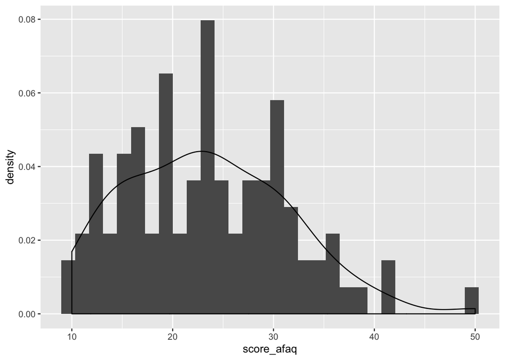

```r
df_afaq %>%
  ggplot(aes(x = score_afaq, y = ..density..)) +
  geom_histogram() +
  geom_density()
```

```r
summary(df_afaq$score_afaq)
```

```
##    Min. 1st Qu.  Median    Mean 3rd Qu.    Max.
##   10.00   16.75   23.00   23.44   29.00   50.00
```

```r
normalidade(df_afaq$score_afaq) %>%
  kable() %>%
  kable_styling()
```

| valor_p | sig |
| --- | --- |
| 0.042 | distribuição não normal |

#### pcs

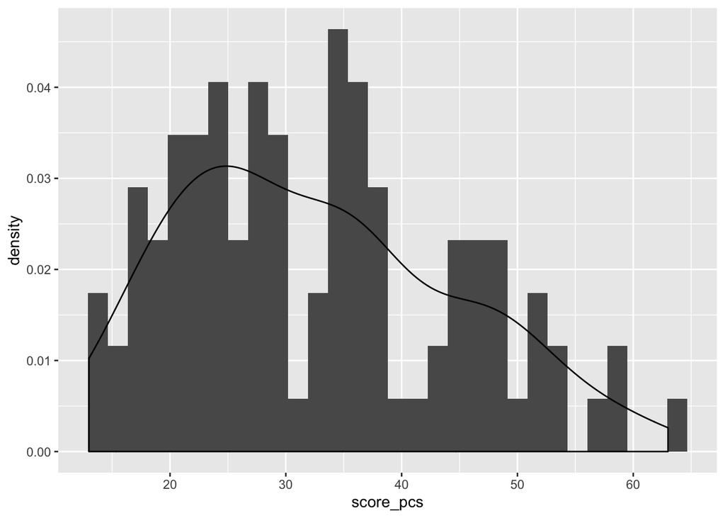

```r
df_pcs %>%
  ggplot(aes(x = score_pcs, y = ..density..)) +
  geom_histogram() +
  geom_density()
```

```r
summary(df_pcs$score_pcs)
```

```
##    Min. 1st Qu.  Median    Mean 3rd Qu.    Max.
##   13.00   23.00   30.50   32.64   40.25   63.00
```

```r
normalidade(df_pcs$score_pcs)%>%
  kable() %>%
  kable_styling()
```

| valor_p | sig |
| --- | --- |
| 0.009 | distribuição não normal |

#### tampa

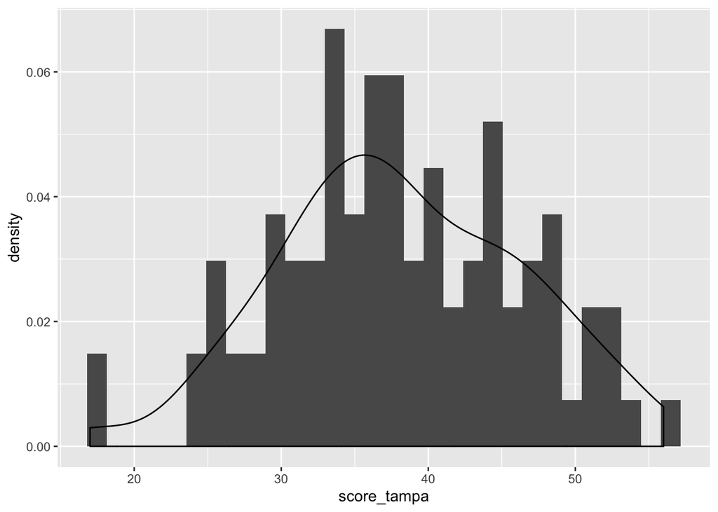

```r
df_tampa_invert %>%
  ggplot(aes(x = score_tampa, y = ..density..)) +
  geom_histogram() +
  geom_density()
```

```r
summary(df_tampa_invert$score_tampa)
```

```
##    Min. 1st Qu.  Median    Mean 3rd Qu.    Max.
##   17.00   32.75   37.50   38.04   44.00   56.00
```

```r
normalidade(df_tampa_invert$score_tampa)%>%
  kable() %>%
  kable_styling()
```

| valor_p | sig |
| --- | --- |
| 0.579 | distribuição normal |

#### fabq

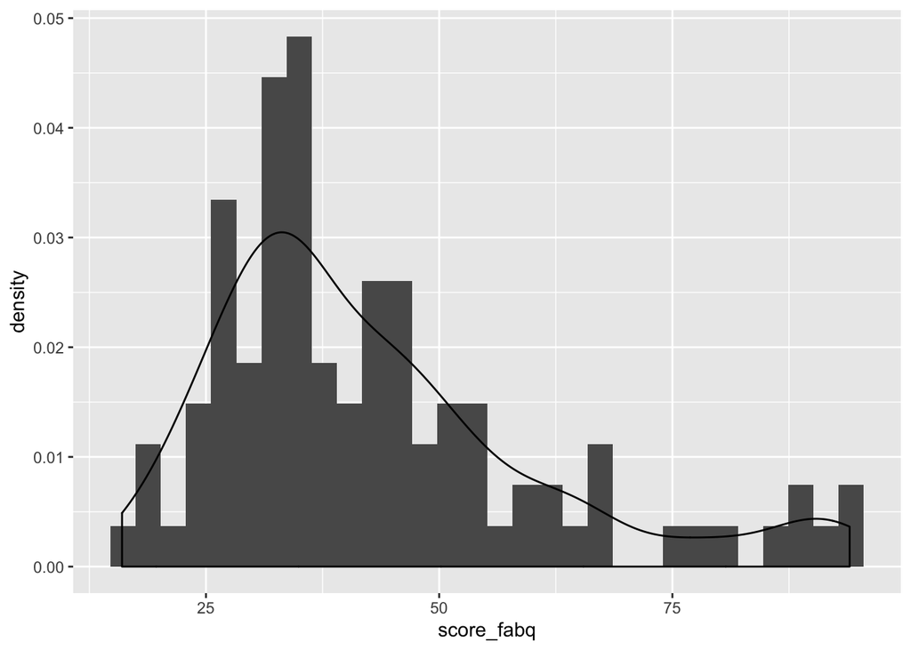

```r
df_fabq %>%
  ggplot(aes(x = score_fabq, y = ..density..)) +
  geom_histogram() +
  geom_density()
```

```r
summary(df_fabq$score_fabq)
```

```
##    Min. 1st Qu.  Median    Mean 3rd Qu.    Max.
##   16.00   31.75   38.00   43.06   50.50   94.00
```

```r
normalidade(df_fabq$score_fabq)%>%
  kable() %>%
  kable_styling()
```

| valor_p | sig |
| --- | --- |
| 0 | distribuição não normal |

## Teste de corelação de spearman rho

### afaq vs pcs

```r
cor.test(x = df_afaq$score_afaq, y = df_pcs$score_pcs, method = c("spearman"))
```

```
##
##  Spearman's rank correlation rho
##
## data:  df_afaq$score_afaq and df_pcs$score_pcs
## S = 76256, p-value = 5.572e-09
## alternative hypothesis: true rho is not equal to 0
## sample estimates:
##       rho
## 0.5424155
```

### afaq vs tampa

```r
cor.test(x = df_afaq$score_afaq, y = df_tampa$score_tampa, method = c("spearman"))
```

```
##
##  Spearman's rank correlation rho
##
## data:  df_afaq$score_afaq and df_tampa$score_tampa
## S = 97484, p-value = 1.759e-05
## alternative hypothesis: true rho is not equal to 0
## sample estimates:
##       rho
## 0.4150377
```

### afaq vs fabq

```r
cor.test(x = df_afaq$score_afaq, y = df_fabq$score_fabq, method = c("spearman"))
```

```
##
##  Spearman's rank correlation rho
##
## data:  df_afaq$score_afaq and df_fabq$score_fabq
## S = 101977, p-value = 6.62e-05
## alternative hypothesis: true rho is not equal to 0
## sample estimates:
##       rho
## 0.3880793
```

### pcs vs tampa

```r
cor.test(x = df_pcs$score_pcs, y = df_tampa$score_tampa, method = c("spearman"))
```

```
##
##  Spearman's rank correlation rho
##
## data:  df_pcs$score_pcs and df_tampa$score_tampa
## S = 83144, p-value = 1.097e-07
## alternative hypothesis: true rho is not equal to 0
## sample estimates:
##       rho
## 0.5010855
```

### pcs vs fabq

```r
cor.test(x = df_pcs$score_pcs, y = df_fabq$score_fabq, method = c("spearman"))
```

```
##
##  Spearman's rank correlation rho
##
## data:  df_pcs$score_pcs and df_fabq$score_fabq
## S = 87907, p-value = 6.924e-07
## alternative hypothesis: true rho is not equal to 0
## sample estimates:
##       rho
## 0.4725032
```

### tampa vs fabq

```r
cor.test(x = df_tampa$score_tampa, y = df_fabq$score_fabq, method = c("spearman"))
```

```
##
##  Spearman's rank correlation rho
##
## data:  df_tampa$score_tampa and df_fabq$score_fabq
## S = 89148, p-value = 1.089e-06
## alternative hypothesis: true rho is not equal to 0
## sample estimates:
##       rho
## 0.4650577
```

## Potential ceiling and floor effects

Os efeitos de teto e piso são considerados presentes se mais de 15% dos entrevistados atingirem a pontuação total mais baixa ou mais alta possível (efeitos de teto e piso não estão relacionados a itens individuais)

```r
df_afaq %>%
  filter(score_afaq == min(score_afaq) | score_afaq == max(score_afaq)) %>%
  group_by(score_afaq) %>%
  summarise(frequência = n()) %>%
  mutate(proporção = paste(frequência/100*100, '%'))%>%
  kable() %>%
  kable_styling()
```

| score_afaq | frequência | proporção |
| --- | --- | --- |
| 10 | 2 | 2 % |
| 50 | 1 | 1 % |

## Análise Fatorial Exploratoria

A análise fatorial é um método estatístico utilizado para descrever a variabilidade entre variáveis observadas e possivelmente correlacionadas em termos de um número potencialmente menor de variáveis não observadas chamadas fatores.

### matriz de correlação

Matriz de correlação entre os os itens de resposta do AFAQ *matcor_afaq: possui o score_total* matcor_afaq_ss: não possui o score_total

### matrix de correlação (grafico)

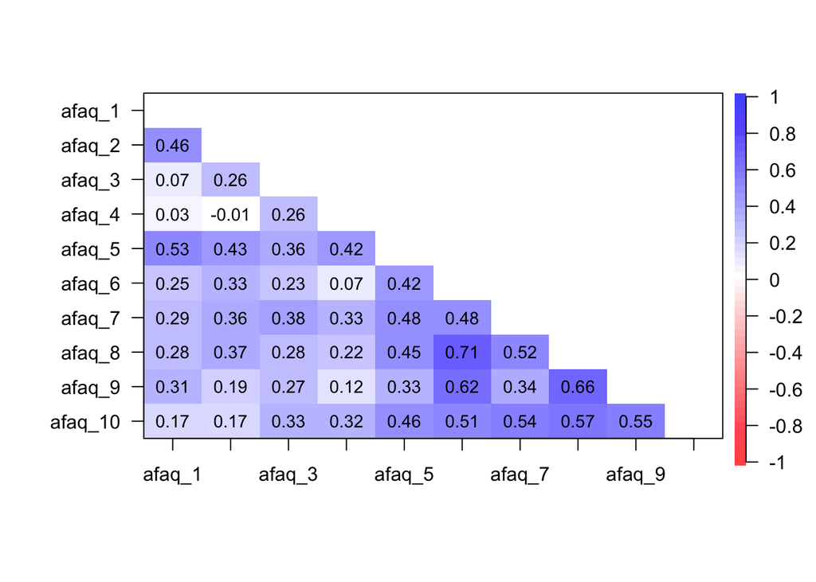

```r
corPlot(matcor_afaq_poly$rho, numbers=TRUE, upper=FALSE, diag=FALSE)
```

## Testar a conveniência do modelo fatorial

### teste de esfericidade de Bartlett

estatística de teste usada para examinar a hipótese de que as variáveis não sejam correlacionadas na população, ou seja, a matriz de correlação da população é uma matriz identidade onde cada variável se correlaciona perfeitamente com ela própria (r=1), mas não apresenta correlação com as outras variáveis (r=0).

```r
cortest.bartlett(matcor_afaq_poly$rho,n=nrow(df5))
```

```
## $chisq
## [1] 400.1467
##
## $p.value
## [1] 1.806403e-58
##
## $df
## [1] 45
```

### kaiser-Meyer-Olkin (KMO)

é o índice usado para avaliar a adequacidade da análise fatorial. Valores altos (entre 0,5 e 1,0) indicam que a análise fatorial é apropriada. Valores abaixo de 0,5 indicam que a análise fatorial pode ser inadequada.

```r
KMO(matcor_afaq_poly$rho)
```

```
## Kaiser-Meyer-Olkin factor adequacy
## Call: KMO(r = matcor_afaq_poly$rho)
## Overall MSA =  0.8
## MSA for each item =
##  afaq_1  afaq_2  afaq_3  afaq_4  afaq_5  afaq_6  afaq_7  afaq_8  afaq_9
##    0.64    0.77    0.80    0.62    0.77    0.83    0.86    0.86    0.77
## afaq_10
##    0.87
```

## Determinando o Número de fatores

### determinando o eigenvalue do AFAQ

```r
fit_afaq<-princomp(matcor_afaq_poly$rho,cor=TRUE)

fit_afaq
```

```
## Call:
## princomp(x = matcor_afaq_poly$rho, cor = TRUE)
##
## Standard deviations:
##    Comp.1    Comp.2    Comp.3    Comp.4    Comp.5    Comp.6    Comp.7
## 1.8338302 1.5947065 1.1572097 1.0553844 0.8100649 0.6554284 0.5411235
##    Comp.8    Comp.9   Comp.10
## 0.4025728 0.3167592 0.0000000
##
##  10  variables and  10 observations.
```

```r
summary(fit_afaq)
```

```
## Importance of components:
##                           Comp.1    Comp.2    Comp.3    Comp.4     Comp.5
## Standard deviation     1.8338302 1.5947065 1.1572097 1.0553844 0.81006485
## Proportion of Variance 0.3362933 0.2543089 0.1339134 0.1113836 0.06562051
## Cumulative Proportion  0.3362933 0.5906022 0.7245156 0.8358993 0.90151976
##                            Comp.6     Comp.7     Comp.8     Comp.9 Comp.10
## Standard deviation     0.65542843 0.54112349 0.40257284 0.31675924       0
## Proportion of Variance 0.04295864 0.02928146 0.01620649 0.01003364       0
## Cumulative Proportion  0.94447841 0.97375987 0.98996636 1.00000000       1
```

### screeplot

Trata-se de uma representação gráfica dos autovalores associada ao número de fatores na ordem de extração. O ponto em que a inclinação suaviza indica o número de fatores a ser usados, que em geral é superior ao revelado pelos autovalores(variancia >1)

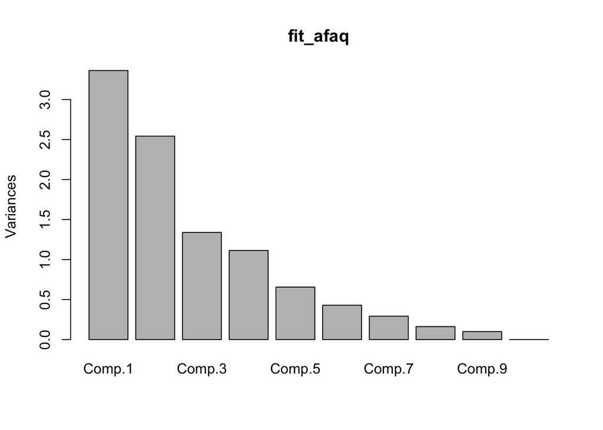

```r
screeplot(fit_afaq)
```

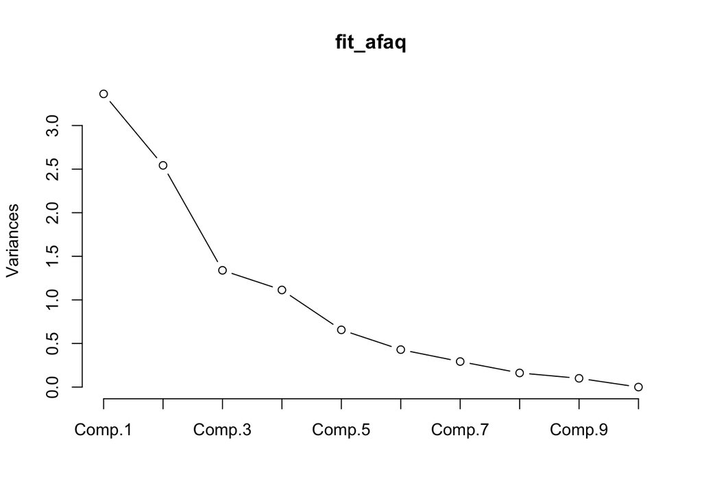

```r
plot(fit_afaq,type="lines")
```

### analise fatorial paralela

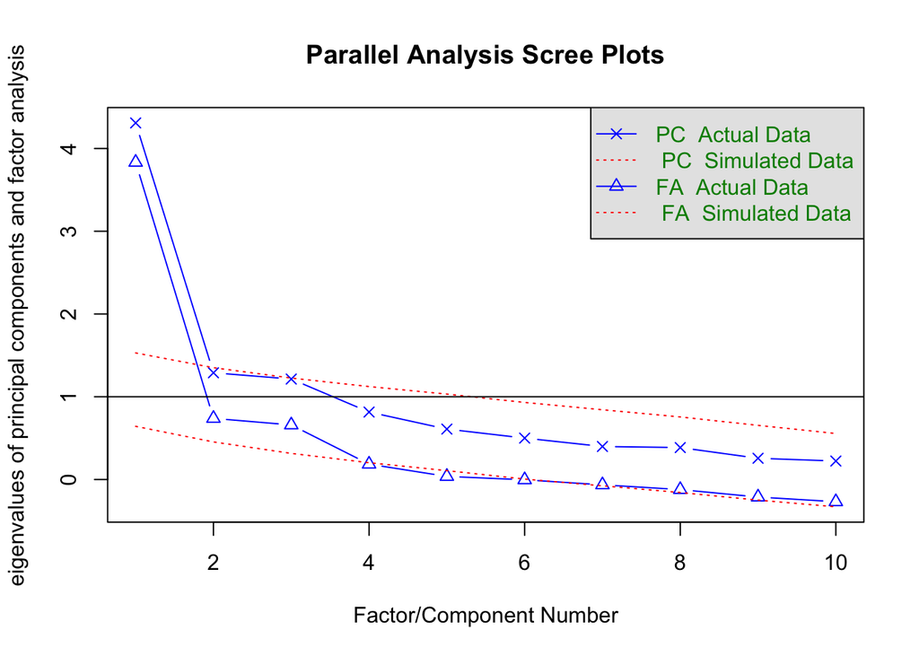

```
## Parallel analysis suggests that the number of factors =  3  and the number of components =  1
```

```r
fa.parallel(matcor_afaq_poly$rho, n.iter=50, SMC=TRUE, show.legend=TRUE)
```

## Determinando o numerode itens

existem duas formas de analizar, utilizando analise de componentes principais ou usando a maxima verossimilhança

### analise de componentes principais (ACP)

```r
PCA_afaq<-principal(matcor_afaq_poly$rho, nfactors=1,
                n.obs=100,rotate="none", scores=TRUE)

PCA_afaq
```

```
## Principal Components Analysis
## Call: principal(r = matcor_afaq_poly$rho, nfactors = 1, rotate = "none",
##     n.obs = 100, scores = TRUE)
## Standardized loadings (pattern matrix) based upon correlation matrix
##          PC1   h2   u2 com
## afaq_1  0.50 0.25 0.75   1
## afaq_2  0.53 0.28 0.72   1
## afaq_3  0.50 0.25 0.75   1
## afaq_4  0.38 0.14 0.86   1
## afaq_5  0.74 0.55 0.45   1
## afaq_6  0.76 0.57 0.43   1
## afaq_7  0.74 0.54 0.46   1
## afaq_8  0.82 0.67 0.33   1
## afaq_9  0.71 0.50 0.50   1
## afaq_10 0.74 0.55 0.45   1
##
##                 PC1
## SS loadings    4.31
## Proportion Var 0.43
##
## Mean item complexity =  1
## Test of the hypothesis that 1 component is sufficient.
##
## The root mean square of the residuals (RMSR) is  0.12
##  with the empirical chi square  131.55  with prob <  4.2e-13
##
## Fit based upon off diagonal values = 0.9
```

## Analise fatorial

```r
afaq_rotacao_obliqua <- fa(matcor_afaq_poly$rho,nfactors=1, n.obs = 100, n.iter=50, rotate="oblimin", fm="ml")


#factor.plot(fa(matcor_afaq_poly$rho, cor = 'poly'))
#fa.diagram(fa(matcor_afaq_poly$rho, cor='poly'), cut=.3)
#irt.fa(df5, plot = TRUE)

round(afaq_rotacao_obliqua$communalities,3)
```

```
##  afaq_1  afaq_2  afaq_3  afaq_4  afaq_5  afaq_6  afaq_7  afaq_8  afaq_9
##   0.161   0.190   0.162   0.086   0.381   0.602   0.430   0.710   0.513
## afaq_10
##   0.491
```

```r
print(afaq_rotacao_obliqua)
```

```
## Factor Analysis with confidence intervals using method = fa(r = matcor_afaq_poly$rho, nfactors = 1, n.obs = 100, n.iter = 50,
##     rotate = "oblimin", fm = "ml")
## Factor Analysis using method =  ml
## Call: fa(r = matcor_afaq_poly$rho, nfactors = 1, n.obs = 100, n.iter = 50,
##     rotate = "oblimin", fm = "ml")
## Standardized loadings (pattern matrix) based upon correlation matrix
##          ML1    h2   u2 com
## afaq_1  0.40 0.161 0.84   1
## afaq_2  0.44 0.190 0.81   1
## afaq_3  0.40 0.162 0.84   1
## afaq_4  0.29 0.086 0.91   1
## afaq_5  0.62 0.381 0.62   1
## afaq_6  0.78 0.602 0.40   1
## afaq_7  0.66 0.430 0.57   1
## afaq_8  0.84 0.710 0.29   1
## afaq_9  0.72 0.513 0.49   1
## afaq_10 0.70 0.491 0.51   1
##
##                 ML1
## SS loadings    3.73
## Proportion Var 0.37
##
## Mean item complexity =  1
## Test of the hypothesis that 1 factor is sufficient.
##
## The degrees of freedom for the null model are  45  and the objective function was  4.22 with Chi Square of  400.15
## The degrees of freedom for the model are 35  and the objective function was  1.18
##
## The root mean square of the residuals (RMSR) is  0.11
## The df corrected root mean square of the residuals is  0.12
##
## The harmonic number of observations is  100 with the empirical chi square  106.74  with prob <  3.5e-09
## The total number of observations was  100  with Likelihood Chi Square =  110.66  with prob <  8.8e-10
##
## Tucker Lewis Index of factoring reliability =  0.724
## RMSEA index =  0.147  and the 90 % confidence intervals are  0.117 0.179
## BIC =  -50.52
## Fit based upon off diagonal values = 0.92
## Measures of factor score adequacy
##                                                    ML1
## Correlation of (regression) scores with factors   0.94
## Multiple R square of scores with factors          0.89
## Minimum correlation of possible factor scores     0.78
##
##  Coefficients and bootstrapped confidence intervals
##          low  ML1 upper
## afaq_1  0.19 0.40  0.60
## afaq_2  0.23 0.44  0.62
## afaq_3  0.16 0.40  0.59
## afaq_4  0.05 0.29  0.52
## afaq_5  0.41 0.62  0.77
## afaq_6  0.64 0.78  0.90
## afaq_7  0.48 0.66  0.79
## afaq_8  0.72 0.84  0.94
## afaq_9  0.57 0.72  0.83
## afaq_10 0.54 0.70  0.81
```

## Diagrama

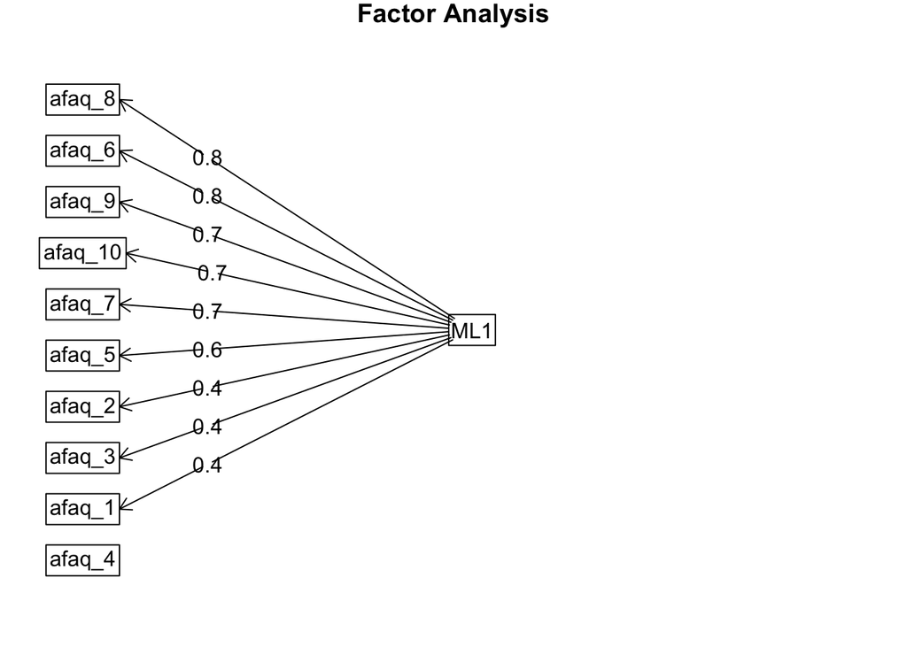

```r
fa.diagram(afaq_rotacao_obliqua)
```

## Análise Fatorial Confirmatoria

### visualização dos dados

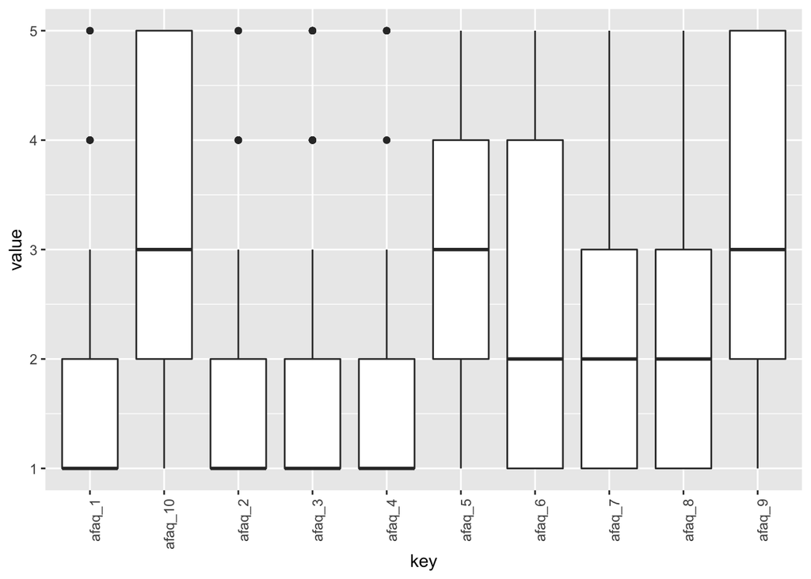

```r
df5 %>%
  gather() %>%
  ggplot(. , aes(key, value)) +
  geom_boxplot() +
  theme(axis.text.x = element_text(angle = 90, hjust = 1))
```

## Analise fatorial confirmatoria (AFC)

```r
mod_afaq <- 'fator_1 =~ afaq_1 + afaq_2 + afaq_3 + afaq_4 + afaq_5 + afaq_6 + afaq_7 + afaq_8 + afaq_9 + afaq_10'

cfa_afaq <- cfa(mod_afaq,
                data = df5,
                missing = "default",
                estimator = "DWLS",
                orthogonal = FALSE,
                ordered = names(df5))

summary(cfa_afaq, standardized=TRUE, fit.measures=TRUE, modindices=FALSE)
```

```
## lavaan 0.6-6 ended normally after 26 iterations
##
##   Estimator                                       DWLS
##   Optimization method                           NLMINB
##   Number of free parameters                         50
##
##   Number of observations                           100
##
## Model Test User Model:
##
##   Test statistic                                48.145
##   Degrees of freedom                                35
##   P-value (Chi-square)                           0.069
##
## Model Test Baseline Model:
##
##   Test statistic                               906.257
##   Degrees of freedom                                45
##   P-value                                        0.000
##
## User Model versus Baseline Model:
##
##   Comparative Fit Index (CFI)                    0.985
##   Tucker-Lewis Index (TLI)                       0.980
##
## Root Mean Square Error of Approximation:
##
##   RMSEA                                          0.062
##   90 Percent confidence interval - lower         0.000
##   90 Percent confidence interval - upper         0.101
##   P-value RMSEA <= 0.05                          0.309
##
## Standardized Root Mean Square Residual:
##
##   SRMR                                           0.097
##
## Parameter Estimates:
##
##   Standard errors                             Standard
##   Information                                 Expected
```

[output cut: 84 more lines]

```
##    .afaq_10           0.509                               0.509    0.509
##     fator_1           0.217    0.054    4.021    0.000    1.000    1.000
##
## Scales y*:
##                    Estimate  Std.Err  z-value  P(>|z|)   Std.lv  Std.all
##     afaq_1            1.000                               1.000    1.000
##     afaq_2            1.000                               1.000    1.000
##     afaq_3            1.000                               1.000    1.000
##     afaq_4            1.000                               1.000    1.000
##     afaq_5            1.000                               1.000    1.000
##     afaq_6            1.000                               1.000    1.000
##     afaq_7            1.000                               1.000    1.000
##     afaq_8            1.000                               1.000    1.000
##     afaq_9            1.000                               1.000    1.000
##     afaq_10           1.000                               1.000    1.000
```

```r
fitMeasures(cfa_afaq, c("chisq", "df", "pvalue", "cfi", "tli", "rmsea"))
```

```
##  chisq     df pvalue    cfi    tli  rmsea
## 48.145 35.000  0.069  0.985  0.980  0.062
```

## Visualizacao grafica

### circulos

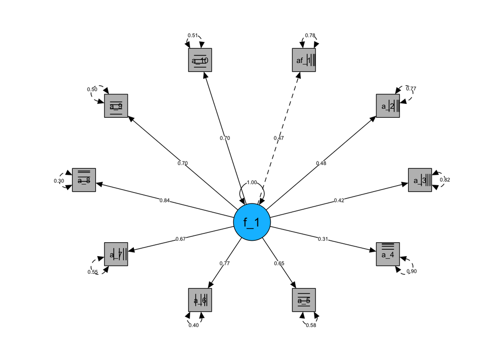

```r
library(semPlot)

semPaths(cfa_afaq,
         whatLabels = "std",
         ##whatlabels = "hide",
         intercepts = FALSE,
         residuals = TRUE,
         edge.label.cex = 0.5,
         layout = "circle2",
         edge.color = "black",
         color = list(lat = "deepskyblue", man = "grey" ))
```

### arvore

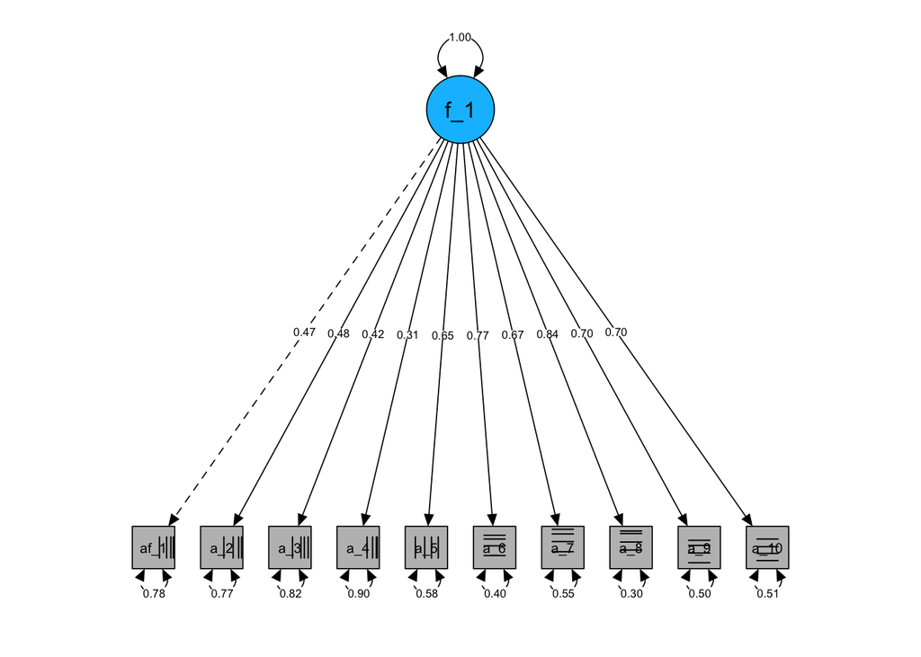

```r
semPaths(cfa_afaq,
         whatLabels = "std",
         #whatlabels = "hide",
         intercepts = FALSE,
         residuals = TRUE,
         edge.label.cex = 0.6,
         layout = "tree2",
         edge.color = "black",
         color = list(lat = "deepskyblue", man = "grey" ))
```